# proyecto_fuga_telco

### Introducción

```python
import sys
print(sys.version)
```

```
3.7.11 (default, Jul 27 2021, 09:42:29) [MSC v.1916 64 bit (AMD64)]
```

```python
#Cargamos el paquete para utilizar el R en el Jupyter Notebook y llevar los objetos al entorno de Python.
%load_ext rpy2.ipython
```

### Carga Paquetes y Librerias

```python
%%R

library(corrplot)
library(data.table)
library(DataExplorer)
library(psych)
library(ggplot2)
library(gmodels) #CrossTable()
library(ggpubr)
library(questionr)
library(scorecard)
library(dummies)
library(MASS)
library(rpart)
library(rpart.plot)
library(caret)
```

```python
%%R

library(caret)
```

### Analisis Exploratorio

```python
%%R

setwd("D:/Caso_Calidda/proyecto/")

data <- as.data.frame(fread("./TelcoCustomerChurn.csv"))

str(data)
```

```
'data.frame':	7043 obs. of  21 variables:
 $ customerID      : chr  "7590-VHVEG" "5575-GNVDE" "3668-QPYBK" "7795-CFOCW" ...
 $ gender          : chr  "Female" "Male" "Male" "Male" ...
 $ SeniorCitizen   : int  0 0 0 0 0 0 0 0 0 0 ...
 $ Partner         : chr  "Yes" "No" "No" "No" ...
 $ Dependents      : chr  "No" "No" "No" "No" ...
 $ tenure          : int  1 34 2 45 2 8 22 10 28 62 ...
 $ PhoneService    : chr  "No" "Yes" "Yes" "No" ...
 $ MultipleLines   : chr  "No phone service" "No" "No" "No phone service" ...
 $ InternetService : chr  "DSL" "DSL" "DSL" "DSL" ...
 $ OnlineSecurity  : chr  "No" "Yes" "Yes" "Yes" ...
 $ OnlineBackup    : chr  "Yes" "No" "Yes" "No" ...
 $ DeviceProtection: chr  "No" "Yes" "No" "Yes" ...
 $ TechSupport     : chr  "No" "No" "No" "Yes" ...
 $ StreamingTV     : chr  "No" "No" "No" "No" ...
 $ StreamingMovies : chr  "No" "No" "No" "No" ...
 $ Contract        : chr  "Month-to-month" "One year" "Month-to-month" "One year" ...
 $ PaperlessBilling: chr  "Yes" "No" "Yes" "No" ...
 $ PaymentMethod   : chr  "Electronic check" "Mailed check" "Mailed check" "Bank transfer (automatic)" ...
 $ MonthlyCharges  : num  29.9 57 53.9 42.3 70.7 ...
 $ TotalCharges    : num  29.9 1889.5 108.2 1840.8 151.7 ...
 $ Churn           : chr  "No" "No" "Yes" "No" ...
```

7043 obs. of 21 variables

```python
%%R

summary(data)
```

```
  customerID           gender          SeniorCitizen      Partner
 Length:7043        Length:7043        Min.   :0.0000   Length:7043
 Class :character   Class :character   1st Qu.:0.0000   Class :character
 Mode  :character   Mode  :character   Median :0.0000   Mode  :character
                                       Mean   :0.1621
                                       3rd Qu.:0.0000
                                       Max.   :1.0000

  Dependents            tenure      PhoneService       MultipleLines
 Length:7043        Min.   : 0.00   Length:7043        Length:7043
 Class :character   1st Qu.: 9.00   Class :character   Class :character
 Mode  :character   Median :29.00   Mode  :character   Mode  :character
                    Mean   :32.37
                    3rd Qu.:55.00
                    Max.   :72.00

 InternetService    OnlineSecurity     OnlineBackup       DeviceProtection
 Length:7043        Length:7043        Length:7043        Length:7043
 Class :character   Class :character   Class :character   Class :character
 Mode  :character   Mode  :character   Mode  :character   Mode  :character




 TechSupport        StreamingTV        StreamingMovies      Contract
 Length:7043        Length:7043        Length:7043        Length:7043
 Class :character   Class :character   Class :character   Class :character
 Mode  :character   Mode  :character   Mode  :character   Mode  :character




 PaperlessBilling   PaymentMethod      MonthlyCharges    TotalCharges
 Length:7043        Length:7043        Min.   : 18.25   Min.   :  18.8
 Class :character   Class :character   1st Qu.: 35.50   1st Qu.: 401.4
 Mode  :character   Mode  :character   Median : 70.35   Median :1397.5
                                       Mean   : 64.76   Mean   :2283.3
                                       3rd Qu.: 89.85   3rd Qu.:3794.7
                                       Max.   :118.75   Max.   :8684.8
                                                        NA's   :11
    Churn
 Length:7043
 Class :character
 Mode  :character
```

La variable SeniorCitizen hay que pasarla a factor La tenure del cliente en promedio es de 32 meses, casi 3 años. No es mucho tiempo LA diferencia entre el promedio de cargo mensual y el cargo total de servicios es considerable. Se asume que el cargo fijo es del servicio total y que el cargo total incluye telefonica fija e internet.

```python
%%R

head(data)
```

```
  customerID gender SeniorCitizen Partner Dependents tenure PhoneService
1 7590-VHVEG Female             0     Yes         No      1           No
2 5575-GNVDE   Male             0      No         No     34          Yes
3 3668-QPYBK   Male             0      No         No      2          Yes
4 7795-CFOCW   Male             0      No         No     45           No
5 9237-HQITU Female             0      No         No      2          Yes
6 9305-CDSKC Female             0      No         No      8          Yes
     MultipleLines InternetService OnlineSecurity OnlineBackup DeviceProtection
1 No phone service             DSL             No          Yes               No
2               No             DSL            Yes           No              Yes
3               No             DSL            Yes          Yes               No
4 No phone service             DSL            Yes           No              Yes
5               No     Fiber optic             No           No               No
6              Yes     Fiber optic             No           No              Yes
  TechSupport StreamingTV StreamingMovies       Contract PaperlessBilling
1          No          No              No Month-to-month              Yes
2          No          No              No       One year               No
3          No          No              No Month-to-month              Yes
4         Yes          No              No       One year               No
5          No          No              No Month-to-month              Yes
6          No         Yes             Yes Month-to-month              Yes
              PaymentMethod MonthlyCharges TotalCharges Churn
1          Electronic check          29.85        29.85    No
2              Mailed check          56.95      1889.50    No
3              Mailed check          53.85       108.15   Yes
4 Bank transfer (automatic)          42.30      1840.75    No
5          Electronic check          70.70       151.65   Yes
6          Electronic check          99.65       820.50   Yes
```

```python
%%R


data$SeniorCitizen<-as.factor(data$SeniorCitizen)
```

```python
%%R
# Cuento el número de valores diferentes para las numéricas
sapply(Filter(is.numeric, data),function(x) length(unique(x)))
```

```
        tenure MonthlyCharges   TotalCharges
            73           1585           6531
```

Hay bastantes valores por lo que no amerita pasar a factor

### Reporte Automatizado

```python
!conda install -c conda-forge pandoc
```

```
^C
```

```python
!pip install --upgrade pandoc
```

https://github.com/jgm/pandoc/releases/tag/1.15.0.6

```python
%%R

#El presente comando abre un reporte web.
create_report(
  data = data,
  output_file = "analisis_exploratorio_automatizado.html",
  output_dir = getwd(),
  config = configure_report()
 )
```

```
R[write to console]:

processing file: report.rmd
```

[output not shown]

[output cut: 53 more lines]

[output not shown]

```
R[write to console]: output file: D:/Caso_Calidda/proyecto/report.knit.md
```

[output not shown]

```
R[write to console]:
Output created: analisis_exploratorio_automatizado.html
```

El reporte automatizado descubrió que para la varianle TotalCharges hay varlores missing. Revisando a detalle son pocos casos y podríamos quitarlo, inckluso no ha habido envento de fuga en ellos Revisando las variables numéricas, estas distan de tener distribución normal, ciertamente están hay muchos valores en los rangos de bajos. REvisando las variables categóricas , hay predominancia de solteros, y de aquellos clientes con servicio de telefonía fija. Por otro lado, respecto a la varaible objetivo Churn, la mayoría no tiene evento de fuga que es lo usual Si bien hay análisis de correlaciones lo veremos a detalle luego. El reporte saca también un análisis de PCA en el que vemos las 3 principales componentes explican el 46.7% de la varaibilidad del total de los datos, no hay predominancia de unas pocas componentes.

```python
%%R
# Distribuciones de numéricas
psych::describe(Filter(is.numeric, data)) #hay otro describe en otra libreria
```

```
               vars    n    mean      sd  median trimmed     mad   min     max
tenure            1 7043   32.37   24.56   29.00   31.43   32.62  0.00   72.00
MonthlyCharges    2 7043   64.76   30.09   70.35   64.97   35.66 18.25  118.75
TotalCharges      3 7032 2283.30 2266.77 1397.47 1970.14 1812.92 18.80 8684.80
                range  skew kurtosis    se
tenure           72.0  0.24    -1.39  0.29
MonthlyCharges  100.5 -0.22    -1.26  0.36
TotalCharges   8666.0  0.96    -0.23 27.03
```

Llama la atención la dispersión (2266) de la variable TotalCharges, los cargos de los otros servicios deben sumar bastante

```python
%%R

#Cargaremos una serie de funciones que utilizaremos más adelante
#relacionado al análisis de variables y su influencia en la variable objetivo
#Estas funciones fueron proporcionadas a lo largo del master.

## NOTA: En general funcionan sobre data.frame, en el caso de tener un objeto tibble y debido a su especial tratamiento
## de subconjuntos seleccionados mediante la indexaciÃ³n de columnas clasica, se pueden producir fallos.
## Lo ideal serÃa convertir a data.frame precvio a la aplicaciÃ³n.

# Carga los paquetes de un vector de entrada y los instala si es necesario (hay una opciÃ³n con una funciÃ³n existente, ver pacman::p_load())
paquetes <- function(x){
  for( i in x ){
    #  require devueleve TRUE (no visible) si se puede cargar el paquete
    if( ! require( i , character.only = TRUE ) ){
      #  En caso negativo lo instala
      install.packages( i , dependencies = TRUE )
      #  Y lo carga
      require( i , character.only = TRUE )
    }
  }
}


# GrÃ¡ficos de inspecciÃ³n rÃ¡pida de un dataset. OpciÃ³n para obtener boxplots
dfplot_box <- function(data.frame, p=2){
#par(mfrow=c(p,p))
  df <- data.frame
  ln <- length(names(data.frame))
  pl<-list()
  for(i in 1:ln){
    if(is.factor(df[,i])){
      b<-barras_cual(df[,i],nombreEje = names(df)[i])
      #print(b)
      } else {

          b<-boxplot_cont(df[,i],nombreEje = names(df)[i])}

  pl[[i]]<-b
  }

return(pl)
}



## Nota: En todos los grÃ¡ficos se puede cambiar el formato tal como colores (fill=''),
## tema grÃ¡fico (theme_whatever()), nombres de ejes, escalas etc.

# Diagrama de barras para las variables cuanlitativas
barras_cual<-function(var,nombreEje){
  dataaux<-data.frame(variable=var)
  ggplot(dataaux, aes(x="All",y = (..count..)/sum(..count..))) +
    geom_bar(aes(var),fill="orchid") + coord_flip()+
    ylab("%")+ xlab(nombreEje)+ theme_light()
}

# Diagrama de cajas para las variables cuantitativas
boxplot_cont<-function(var,nombreEje){
  dataaux<-data.frame(variable=var)
  ggplot(dataaux,aes(y=variable))+
    geom_boxplot(aes(x=""),notch=TRUE, fill="orchid") +
    stat_summary(aes(x="") ,fun.y=mean, geom="point", shape=8) +
    xlab(nombreEje)+ theme_light()+ theme(axis.title.y = element_blank())
}


# Diagrama de cajas para las variables cuantitativas y variable objetivo binaria
boxplot_targetbinaria<-function(var,target,nombreEje){
  dataaux<-data.frame(variable=var,target=target)
  ggplot(dataaux,aes(y=var))+
    geom_boxplot(aes(x="All"), notch=TRUE, fill="grey") +
    stat_summary(aes(x="All"), fun.y=mean, geom="point", shape=8) +
    geom_boxplot(aes(x=target, fill=target), notch=TRUE) +
    stat_summary(aes(x=target), fun.y=mean, geom="point", shape=8) +
    ylab(nombreEje)
}


# Cuenta el nÃºmero de atÃpicos y los transforma en missings (esta funciÃ³n retorna 2 valores, la variable ya
# transformada con los outliers como missing y el conteo de outliers para hacerse una idea.
atipicosAmissing<-function(varaux){
  if (abs(skew(varaux))<1){
    criterio1<-abs((varaux-mean(varaux,na.rm=T))/sd(varaux,na.rm=T))>3
  } else {
    criterio1<-abs((varaux-median(varaux,na.rm=T))/mad(varaux,na.rm=T))>8
  }
  qnt <- quantile(varaux, probs=c(.25, .75), na.rm = T)
  H <- 3 * IQR(varaux, na.rm = T)
  criterio2<-(varaux<(qnt[1] - H))|(varaux>(qnt[2] + H))
  varaux[criterio1&criterio2]<-NA
  return(list(varaux,sum(criterio1&criterio2,na.rm=T)))
}


# Calcula el V de Cramer
Vcramer<-function(v,target){
  if (is.numeric(v)){
    v<-cut(v,5)
  }
  if (is.numeric(target)){
    target<-cut(target,5)
  }
  cramer.v(table(v,target))
}

# Busca la transformaciÃ³n de variables input de intervalo que maximiza la V de Cramer con la objetivo binaria
mejorTransfVcramer<-function(vv,target){
  vv<-scale(vv)
  vv<-vv+abs(min(vv,na.rm=T))*1.0001
  posiblesTransf<-data.frame(x=vv,logx=log(vv),expx=exp(vv),sqrx=vv^2,sqrtx=sqrt(vv),cuartax=vv^4,raiz4=vv^(1/4))
  return(list(colnames(posiblesTransf)[which.max(apply(posiblesTransf,2,function(x) Vcramer(x,target)))],posiblesTransf[,which.max(apply(posiblesTransf,2,function(x) Vcramer(x,target)))]))
}


# GrÃ¡fico con el V de cramer de todas las variables input para saber su importancia
graficoVcramer<-function(matriz, target){
  salidaVcramer<-sapply(matriz,function(x) Vcramer(x,target))
  barplot(sort(salidaVcramer,decreasing =T),las=2,ylim=c(0,1))
}


#GrÃ¡fico con la importancia de las variables en regr. logÃstica
impVariablesLog<-function(modelo,nombreVar,dd=data_train){
  null<-glm(as.formula(paste(nombreVar,"~1")),data=dd,family=binomial)
  aux2<-capture.output(aux<-step(modelo, scope=list(lower=null, upper=modelo), direction="backward",k=0,steps=1))
  aux3<-read.table(textConnection(aux2[grep("-",aux2)]))[,c(2,5)]
  aux3$V5<-(aux3$V5-modelo$deviance)/modelo$null.deviance
  barplot(aux3$V5,names.arg = aux3$V2,las=2,horiz=T,main="Importancia de las variables (Pseudo-R2)")
}

#Calcula medidas de calidad para un punto de corte dado
sensEspCorte<-function(modelo,dd,nombreVar,ptoCorte,evento){
  probs <-predict(modelo,newdata=dd,type="response")
  cm<-confusionMatrix(data=factor(ifelse(probs>ptoCorte,1,0)), reference=dd[,nombreVar],positive=evento)
  c(cm$overall[1],cm$byClass[1:4])
}

#Generar todas las posibles interacciones
formulaInteracciones<-function(data,posicion){
  listaFactores<-c()
  lista<-paste(names(data)[posicion],'~')
  nombres<-names(data)
  for (i in (1:length(nombres))[-posicion]){
    lista<-paste(lista,nombres[i],'+')
    if (class(data[,i])=="factor"){
      listaFactores<-c(listaFactores,i)
      for (j in ((1:length(nombres))[-c(posicion,listaFactores)])){
        lista<-paste(lista,nombres[i],':',nombres[j],'+')
      }
    }
  }
  lista<-substr(lista, 1, nchar(lista)-1)
  lista
}
```

```python
%%R

# % de atipicos por variable
sapply(Filter(is.numeric, data),function(x) atipicosAmissing(x)[[2]])/nrow(data)
```

```
        tenure MonthlyCharges   TotalCharges
             0              0              0
```

```python
%%R

#variables caracter la pasamos a factor
for(i in 1:ncol(data)){
  if(is.character(data[,i])){
    print(i)
    data[,i]<-as.factor(data[,i])
  }
}
```

```
[1] 1
[1] 2
[1] 4
[1] 5
[1] 7
[1] 8
[1] 9
[1] 10
[1] 11
[1] 12
[1] 13
[1] 14
[1] 15
[1] 16
[1] 17
[1] 18
[1] 21
```

Ver el reparto de las categorìas de las variables cualitativas

```python
%%R

customerID <-data$customerID
data <- subset( data, select = - customerID )
```

```python
%%R

lapply(Filter(is.factor,data),questionr::freq)
```

```
$gender
          n    % val%
Female 3488 49.5 49.5
Male   3555 50.5 50.5

$SeniorCitizen
     n    % val%
0 5901 83.8 83.8
1 1142 16.2 16.2

$Partner
       n    % val%
No  3641 51.7 51.7
Yes 3402 48.3 48.3

$Dependents
       n  % val%
No  4933 70   70
Yes 2110 30   30

$PhoneService
       n    % val%
No   682  9.7  9.7
Yes 6361 90.3 90.3

$MultipleLines
                    n    % val%
No               3390 48.1 48.1
No phone service  682  9.7  9.7
Yes              2971 42.2 42.2

$InternetService
               n    % val%
DSL         2421 34.4 34.4
Fiber optic 3096 44.0 44.0
No          1526 21.7 21.7

$OnlineSecurity
                       n    % val%
No                  3498 49.7 49.7
```

[output cut: 40 more lines]

```
       n    % val%
No  2872 40.8 40.8
Yes 4171 59.2 59.2

$PaymentMethod
                             n    % val%
Bank transfer (automatic) 1544 21.9 21.9
Credit card (automatic)   1522 21.6 21.6
Electronic check          2365 33.6 33.6
Mailed check              1612 22.9 22.9

$Churn
       n    % val%
No  5174 73.5 73.5
Yes 1869 26.5 26.5
```

El 26% ha tenido evento Churn por lo que se asume un submuestreo para balancear mejor los datos

```python
%%R

pl_box<-dfplot_box(data)
```

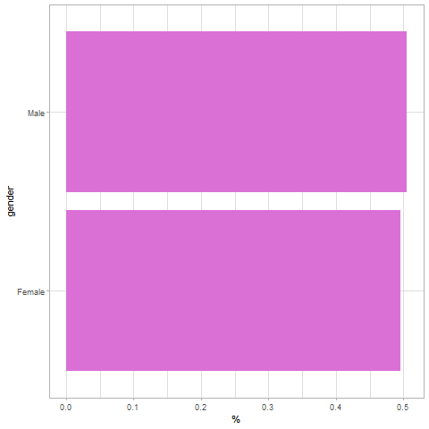

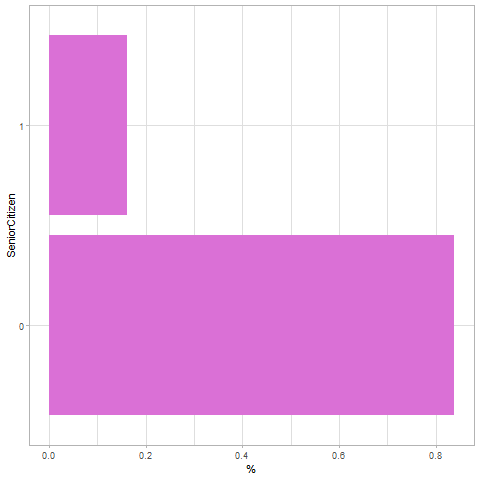

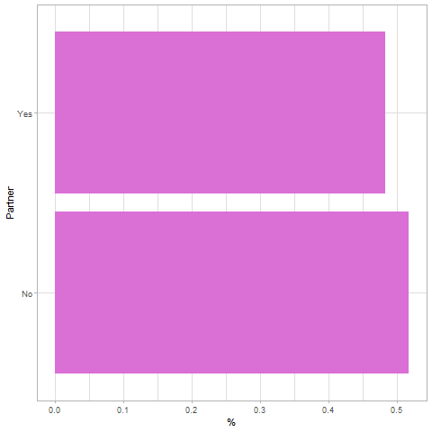

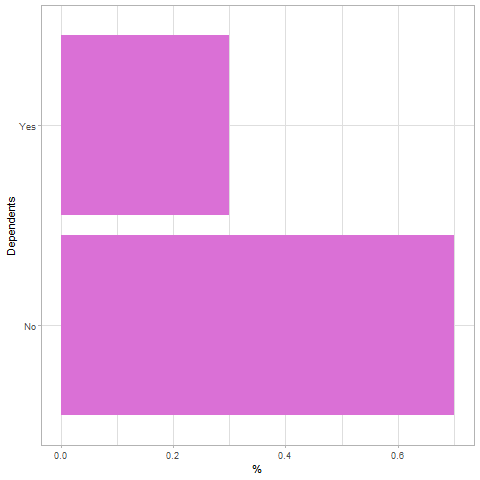

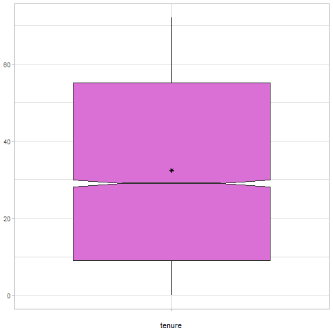

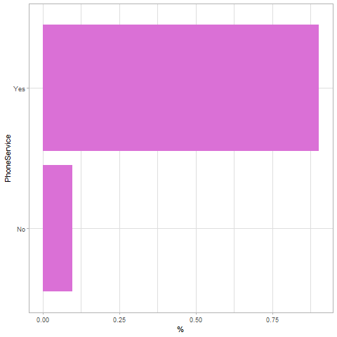

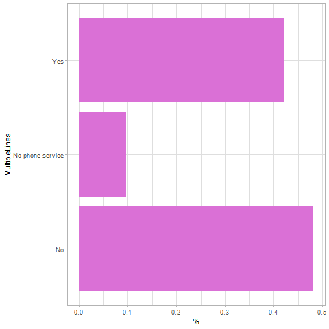

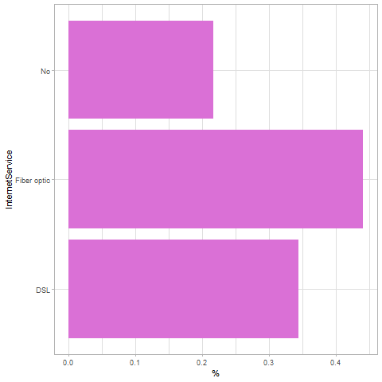

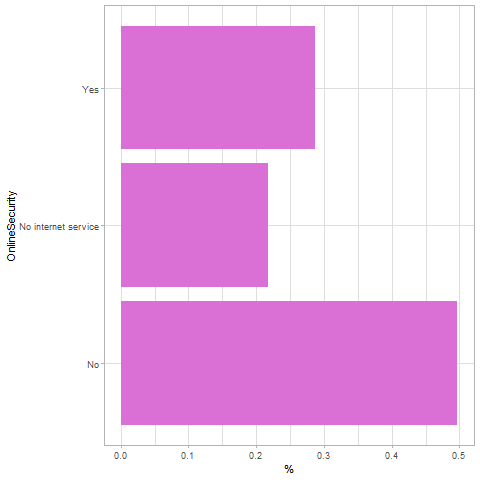

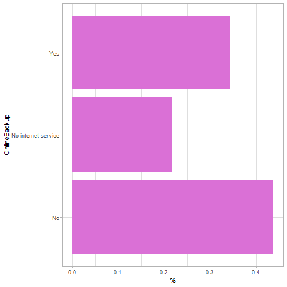

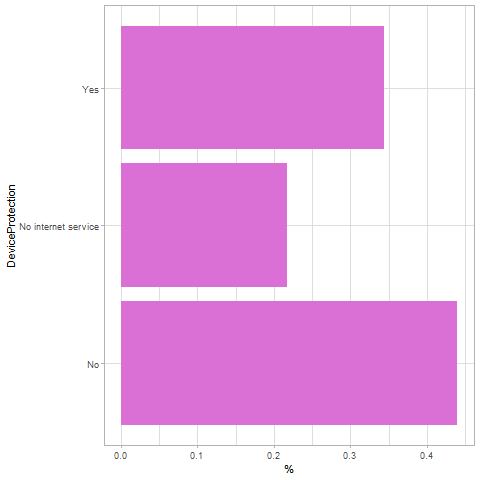

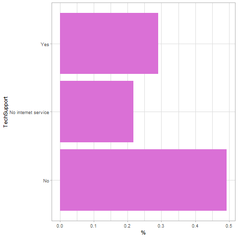

[8 more figures not shown]

```python
%%R

# Crear rejilla gráfica de 2x2
#marrangeGrob(pl_box, nrow=2, ncol=2)
pl_box
```

### Análisis de Asociaciones y Correlaciones

```python
%%R

CrossTable(x=data$PhoneService, y=data$Churn, prop.r=TRUE,
           prop.c=FALSE, prop.t=FALSE, prop.chisq=TRUE,
           chisq = TRUE, format="SPSS",digits = 2)
```

```
   Cell Contents
|-------------------------|
|                   Count |
| Chi-square contribution |
|             Row Percent |
|-------------------------|

Total Observations in Table:  7043

                  | data$Churn
data$PhoneService |       No  |      Yes  | Row Total |
------------------|-----------|-----------|-----------|
               No |      512  |      170  |      682  |
                  |     0.24  |     0.67  |           |
                  |    75.07% |    24.93% |     9.68% |
------------------|-----------|-----------|-----------|
              Yes |     4662  |     1699  |     6361  |
                  |     0.03  |     0.07  |           |
                  |    73.29% |    26.71% |    90.32% |
------------------|-----------|-----------|-----------|
     Column Total |     5174  |     1869  |     7043  |
------------------|-----------|-----------|-----------|


Statistics for All Table Factors


Pearson's Chi-squared test
------------------------------------------------------------
Chi^2 =  1.004408     d.f. =  1     p =  0.3162461

Pearson's Chi-squared test with Yates' continuity correction
------------------------------------------------------------
Chi^2 =  0.915033     d.f. =  1     p =  0.3387825


       Minimum expected frequency: 180.9823
```

No hay asociación entre la tenencia de telefonía fija y el churn

```python
%%R

CrossTable(x=data$MultipleLines, y=data$Churn, prop.r=TRUE,
           prop.c=FALSE, prop.t=FALSE, prop.chisq=TRUE,
           chisq = TRUE, format="SPSS",digits = 2)
```

```
   Cell Contents
|-------------------------|
|                   Count |
| Chi-square contribution |
|             Row Percent |
|-------------------------|

Total Observations in Table:  7043

                   | data$Churn
data$MultipleLines |       No  |      Yes  | Row Total |
-------------------|-----------|-----------|-----------|
                No |     2541  |      849  |     3390  |
                   |     1.03  |     2.85  |           |
                   |    74.96% |    25.04% |    48.13% |
-------------------|-----------|-----------|-----------|
  No phone service |      512  |      170  |      682  |
                   |     0.24  |     0.67  |           |
                   |    75.07% |    24.93% |     9.68% |
-------------------|-----------|-----------|-----------|
               Yes |     2121  |      850  |     2971  |
                   |     1.74  |     4.81  |           |
                   |    71.39% |    28.61% |    42.18% |
-------------------|-----------|-----------|-----------|
      Column Total |     5174  |     1869  |     7043  |
-------------------|-----------|-----------|-----------|


Statistics for All Table Factors


Pearson's Chi-squared test
------------------------------------------------------------
Chi^2 =  11.33044     d.f. =  2     p =  0.003464383



       Minimum expected frequency: 180.9823
```

Se presume sí hay diferencia significativa entre tener una o varias o ninguna líneas de telefonía fija aunque la diferencia es estadísticamente poco significativa.

```python
%%R

CrossTable(x=data$InternetService, y=data$Churn, prop.r=TRUE,
           prop.c=FALSE, prop.t=FALSE, prop.chisq=TRUE,
           chisq = TRUE, format="SPSS",digits = 2)
```

```
   Cell Contents
|-------------------------|
|                   Count |
| Chi-square contribution |
|             Row Percent |
|-------------------------|

Total Observations in Table:  7043

                     | data$Churn
data$InternetService |       No  |      Yes  | Row Total |
---------------------|-----------|-----------|-----------|
                 DSL |     1962  |      459  |     2421  |
                     |    18.92  |    52.39  |           |
                     |    81.04% |    18.96% |    34.37% |
---------------------|-----------|-----------|-----------|
         Fiber optic |     1799  |     1297  |     3096  |
                     |    99.37  |   275.10  |           |
                     |    58.11% |    41.89% |    43.96% |
---------------------|-----------|-----------|-----------|
                  No |     1413  |      113  |     1526  |
                     |    76.03  |   210.49  |           |
                     |    92.60% |     7.40% |    21.67% |
---------------------|-----------|-----------|-----------|
        Column Total |     5174  |     1869  |     7043  |
---------------------|-----------|-----------|-----------|


Statistics for All Table Factors


Pearson's Chi-squared test
------------------------------------------------------------
Chi^2 =  732.3096     d.f. =  2     p =  9.571788e-160



       Minimum expected frequency: 404.9544
```

Aquí es más notoria la diferencia de churn entre los tipos de servicio de internet, donde el grupo de clientes con fibra óptica tiene un churn de casi 42%. Incluso tener DSL supera el doble de Churn de quienes no tienen.

```python
%%R

CrossTable(x=data$OnlineSecurity, y=data$Churn, prop.r=TRUE,
           prop.c=FALSE, prop.t=FALSE, prop.chisq=TRUE,
           chisq = TRUE, format="SPSS",digits = 2)
```

```
   Cell Contents
|-------------------------|
|                   Count |
| Chi-square contribution |
|             Row Percent |
|-------------------------|

Total Observations in Table:  7043

                    | data$Churn
data$OnlineSecurity |       No  |      Yes  | Row Total |
--------------------|-----------|-----------|-----------|
                 No |     2037  |     1461  |     3498  |
                    |   110.44  |   305.74  |           |
                    |    58.23% |    41.77% |    49.67% |
--------------------|-----------|-----------|-----------|
No internet service |     1413  |      113  |     1526  |
                    |    76.03  |   210.49  |           |
                    |    92.60% |     7.40% |    21.67% |
--------------------|-----------|-----------|-----------|
                Yes |     1724  |      295  |     2019  |
                    |    39.09  |   108.21  |           |
                    |    85.39% |    14.61% |    28.67% |
--------------------|-----------|-----------|-----------|
       Column Total |     5174  |     1869  |     7043  |
--------------------|-----------|-----------|-----------|


Statistics for All Table Factors


Pearson's Chi-squared test
------------------------------------------------------------
Chi^2 =  849.999     d.f. =  2     p =  2.66115e-185



       Minimum expected frequency: 404.9544
```

```python
%%R

CrossTable(x=data$OnlineBackup, y=data$Churn, prop.r=TRUE,
           prop.c=FALSE, prop.t=FALSE, prop.chisq=TRUE,
           chisq = TRUE, format="SPSS",digits = 2)
```

```
   Cell Contents
|-------------------------|
|                   Count |
| Chi-square contribution |
|             Row Percent |
|-------------------------|

Total Observations in Table:  7043

                    | data$Churn
  data$OnlineBackup |       No  |      Yes  | Row Total |
--------------------|-----------|-----------|-----------|
                 No |     1855  |     1233  |     3088  |
                    |    75.38  |   208.69  |           |
                    |    60.07% |    39.93% |    43.84% |
--------------------|-----------|-----------|-----------|
No internet service |     1413  |      113  |     1526  |
                    |    76.03  |   210.49  |           |
                    |    92.60% |     7.40% |    21.67% |
--------------------|-----------|-----------|-----------|
                Yes |     1906  |      523  |     2429  |
                    |     8.28  |    22.93  |           |
                    |    78.47% |    21.53% |    34.49% |
--------------------|-----------|-----------|-----------|
       Column Total |     5174  |     1869  |     7043  |
--------------------|-----------|-----------|-----------|


Statistics for All Table Factors


Pearson's Chi-squared test
------------------------------------------------------------
Chi^2 =  601.8128     d.f. =  2     p =  2.079759e-131



       Minimum expected frequency: 404.9544
```

El grupo de cliente con internet pero que no tienen OnlineBackup tiene una tasa de fuga de casi 40%

```python
%%R

CrossTable(x=data$DeviceProtection, y=data$Churn, prop.r=TRUE,
           prop.c=FALSE, prop.t=FALSE, prop.chisq=TRUE,
           chisq = TRUE, format="SPSS",digits = 2)
```

```
   Cell Contents
|-------------------------|
|                   Count |
| Chi-square contribution |
|             Row Percent |
|-------------------------|

Total Observations in Table:  7043

                      | data$Churn
data$DeviceProtection |       No  |      Yes  | Row Total |
----------------------|-----------|-----------|-----------|
                   No |     1884  |     1211  |     3095  |
                      |    66.79  |   184.89  |           |
                      |    60.87% |    39.13% |    43.94% |
----------------------|-----------|-----------|-----------|
  No internet service |     1413  |      113  |     1526  |
                      |    76.03  |   210.49  |           |
                      |    92.60% |     7.40% |    21.67% |
----------------------|-----------|-----------|-----------|
                  Yes |     1877  |      545  |     2422  |
                      |     5.37  |    14.86  |           |
                      |    77.50% |    22.50% |    34.39% |
----------------------|-----------|-----------|-----------|
         Column Total |     5174  |     1869  |     7043  |
----------------------|-----------|-----------|-----------|


Statistics for All Table Factors


Pearson's Chi-squared test
------------------------------------------------------------
Chi^2 =  558.4194     d.f. =  2     p =  5.505219e-122



       Minimum expected frequency: 404.9544
```

El grupo de clientes sin DeviceProtection tiene tasa de fuga de casi 40%, mucho mayor que los demás. Aquí se nos advierte que el número mínimo esperado por grupo debería se de más de 400 casos

```python
%%R

CrossTable(x=data$TechSupport, y=data$Churn, prop.r=TRUE,
           prop.c=FALSE, prop.t=FALSE, prop.chisq=TRUE,
           chisq = TRUE, format="SPSS",digits = 2)
```

```
   Cell Contents
|-------------------------|
|                   Count |
| Chi-square contribution |
|             Row Percent |
|-------------------------|

Total Observations in Table:  7043

                    | data$Churn
   data$TechSupport |       No  |      Yes  | Row Total |
--------------------|-----------|-----------|-----------|
                 No |     2027  |     1446  |     3473  |
                    |   107.77  |   298.35  |           |
                    |    58.36% |    41.64% |    49.31% |
--------------------|-----------|-----------|-----------|
No internet service |     1413  |      113  |     1526  |
                    |    76.03  |   210.49  |           |
                    |    92.60% |     7.40% |    21.67% |
--------------------|-----------|-----------|-----------|
                Yes |     1734  |      310  |     2044  |
                    |    35.97  |    99.59  |           |
                    |    84.83% |    15.17% |    29.02% |
--------------------|-----------|-----------|-----------|
       Column Total |     5174  |     1869  |     7043  |
--------------------|-----------|-----------|-----------|


Statistics for All Table Factors


Pearson's Chi-squared test
------------------------------------------------------------
Chi^2 =  828.1971     d.f. =  2     p =  1.443084e-180



       Minimum expected frequency: 404.9544
```

Los clientes con internet sin TechSupport tiene más de 41% de churn

```python
%%R

CrossTable(x=data$StreamingTV, y=data$Churn, prop.r=TRUE,
           prop.c=FALSE, prop.t=FALSE, prop.chisq=TRUE,
           chisq = TRUE, format="SPSS",digits = 2)
```

```
   Cell Contents
|-------------------------|
|                   Count |
| Chi-square contribution |
|             Row Percent |
|-------------------------|

Total Observations in Table:  7043

                    | data$Churn
   data$StreamingTV |       No  |      Yes  | Row Total |
--------------------|-----------|-----------|-----------|
                 No |     1868  |      942  |     2810  |
                    |    18.67  |    51.68  |           |
                    |    66.48% |    33.52% |    39.90% |
--------------------|-----------|-----------|-----------|
No internet service |     1413  |      113  |     1526  |
                    |    76.03  |   210.49  |           |
                    |    92.60% |     7.40% |    21.67% |
--------------------|-----------|-----------|-----------|
                Yes |     1893  |      814  |     2707  |
                    |     4.60  |    12.73  |           |
                    |    69.93% |    30.07% |    38.44% |
--------------------|-----------|-----------|-----------|
       Column Total |     5174  |     1869  |     7043  |
--------------------|-----------|-----------|-----------|


Statistics for All Table Factors


Pearson's Chi-squared test
------------------------------------------------------------
Chi^2 =  374.2039     d.f. =  2     p =  5.528994e-82



       Minimum expected frequency: 404.9544
```

TEner o no tener StreamingTV no tiene mucha diferencia en su churn pero sí con respecto al grupo que no tiene servicio de internet que es algo ya visto anteriormente.

```python
%%R

CrossTable(x=data$StreamingMovies, y=data$Churn, prop.r=TRUE,
           prop.c=FALSE, prop.t=FALSE, prop.chisq=TRUE,
           chisq = TRUE, format="SPSS",digits = 2)
```

```
   Cell Contents
|-------------------------|
|                   Count |
| Chi-square contribution |
|             Row Percent |
|-------------------------|

Total Observations in Table:  7043

                     | data$Churn
data$StreamingMovies |       No  |      Yes  | Row Total |
---------------------|-----------|-----------|-----------|
                  No |     1847  |      938  |     2785  |
                     |    19.35  |    53.55  |           |
                     |    66.32% |    33.68% |    39.54% |
---------------------|-----------|-----------|-----------|
 No internet service |     1413  |      113  |     1526  |
                     |    76.03  |   210.49  |           |
                     |    92.60% |     7.40% |    21.67% |
---------------------|-----------|-----------|-----------|
                 Yes |     1914  |      818  |     2732  |
                     |     4.31  |    11.93  |           |
                     |    70.06% |    29.94% |    38.79% |
---------------------|-----------|-----------|-----------|
        Column Total |     5174  |     1869  |     7043  |
---------------------|-----------|-----------|-----------|


Statistics for All Table Factors


Pearson's Chi-squared test
------------------------------------------------------------
Chi^2 =  375.6615     d.f. =  2     p =  2.667757e-82



       Minimum expected frequency: 404.9544
```

Tener o no tener StreamingMovies no tiene mucha diferencia en su churn pero sí con respecto al grupo que no tiene servicio de internet que es algo ya visto anteriormente.

```python
%%R

CrossTable(x=data$Contract, y=data$Churn, prop.r=TRUE,
           prop.c=FALSE, prop.t=FALSE, prop.chisq=TRUE,
           chisq = TRUE, format="SPSS",digits = 2)
```

```
   Cell Contents
|-------------------------|
|                   Count |
| Chi-square contribution |
|             Row Percent |
|-------------------------|

Total Observations in Table:  7043

               | data$Churn
 data$Contract |       No  |      Yes  | Row Total |
---------------|-----------|-----------|-----------|
Month-to-month |     2220  |     1655  |     3875  |
               |   137.96  |   381.93  |           |
               |    57.29% |    42.71% |    55.02% |
---------------|-----------|-----------|-----------|
      One year |     1307  |      166  |     1473  |
               |    46.74  |   129.39  |           |
               |    88.73% |    11.27% |    20.91% |
---------------|-----------|-----------|-----------|
      Two year |     1647  |       48  |     1695  |
               |   129.65  |   358.92  |           |
               |    97.17% |     2.83% |    24.07% |
---------------|-----------|-----------|-----------|
  Column Total |     5174  |     1869  |     7043  |
---------------|-----------|-----------|-----------|


Statistics for All Table Factors


Pearson's Chi-squared test
------------------------------------------------------------
Chi^2 =  1184.597     d.f. =  2     p =  5.863038e-258



       Minimum expected frequency: 390.8898
```

Era de eseperarse que los clientes que tiene contratos largos tengan menor tasa de fuga. Esto es por las penalidades que involucran

```python
%%R

CrossTable(x=data$PaperlessBilling, y=data$Churn, prop.r=TRUE,
           prop.c=FALSE, prop.t=FALSE, prop.chisq=TRUE,
           chisq = TRUE, format="SPSS",digits = 2)
```

```
   Cell Contents
|-------------------------|
|                   Count |
| Chi-square contribution |
|             Row Percent |
|-------------------------|

Total Observations in Table:  7043

                      | data$Churn
data$PaperlessBilling |       No  |      Yes  | Row Total |
----------------------|-----------|-----------|-----------|
                   No |     2403  |      469  |     2872  |
                      |    40.73  |   112.75  |           |
                      |    83.67% |    16.33% |    40.78% |
----------------------|-----------|-----------|-----------|
                  Yes |     2771  |     1400  |     4171  |
                      |    28.04  |    77.64  |           |
                      |    66.43% |    33.57% |    59.22% |
----------------------|-----------|-----------|-----------|
         Column Total |     5174  |     1869  |     7043  |
----------------------|-----------|-----------|-----------|


Statistics for All Table Factors


Pearson's Chi-squared test
------------------------------------------------------------
Chi^2 =  259.161     d.f. =  1     p =  2.614597e-58

Pearson's Chi-squared test with Yates' continuity correction
------------------------------------------------------------
Chi^2 =  258.2776     d.f. =  1     p =  4.073355e-58


       Minimum expected frequency: 762.1423
```

Los clientes que tienen PaperlessBilling están teniendo más del doble de tasa de fuga

```python
%%R

CrossTable(x=data$PaymentMethod, y=data$Churn, prop.r=TRUE,
           prop.c=FALSE, prop.t=FALSE, prop.chisq=TRUE,
           chisq = TRUE, format="SPSS",digits = 2)
```

```
   Cell Contents
|-------------------------|
|                   Count |
| Chi-square contribution |
|             Row Percent |
|-------------------------|

Total Observations in Table:  7043

                          | data$Churn
       data$PaymentMethod |       No  |      Yes  | Row Total |
--------------------------|-----------|-----------|-----------|
Bank transfer (automatic) |     1286  |      258  |     1544  |
                          |    20.30  |    56.19  |           |
                          |    83.29% |    16.71% |    21.92% |
--------------------------|-----------|-----------|-----------|
  Credit card (automatic) |     1290  |      232  |     1522  |
                          |    26.43  |    73.16  |           |
                          |    84.76% |    15.24% |    21.61% |
--------------------------|-----------|-----------|-----------|
         Electronic check |     1294  |     1071  |     2365  |
                          |   113.16  |   313.26  |           |
                          |    54.71% |    45.29% |    33.58% |
--------------------------|-----------|-----------|-----------|
             Mailed check |     1304  |      308  |     1612  |
                          |    12.11  |    33.54  |           |
                          |    80.89% |    19.11% |    22.89% |
--------------------------|-----------|-----------|-----------|
             Column Total |     5174  |     1869  |     7043  |
--------------------------|-----------|-----------|-----------|


Statistics for All Table Factors


Pearson's Chi-squared test
------------------------------------------------------------
Chi^2 =  648.1423     d.f. =  3     p =  3.682355e-140



       Minimum expected frequency: 403.8929
```

PArece haber problemas con el grupo con tipo de pago: Electronic check

```python
%%R

(colMeans(is.na(data)))*100
```

```
          gender    SeniorCitizen          Partner       Dependents
       0.0000000        0.0000000        0.0000000        0.0000000
          tenure     PhoneService    MultipleLines  InternetService
       0.0000000        0.0000000        0.0000000        0.0000000
  OnlineSecurity     OnlineBackup DeviceProtection      TechSupport
       0.0000000        0.0000000        0.0000000        0.0000000
     StreamingTV  StreamingMovies         Contract PaperlessBilling
       0.0000000        0.0000000        0.0000000        0.0000000
   PaymentMethod   MonthlyCharges     TotalCharges            Churn
       0.0000000        0.0000000        0.1561834        0.0000000
```

Tenemos menos de 1% de missings en TotalCharges

Vamos a imputar datos

```python
%%R

set.seed(123)
inputs<- Hmisc::aregImpute(~TotalCharges+MultipleLines+OnlineSecurity+DeviceProtection+TechSupport +StreamingTV +MonthlyCharges, data = data, n.impute = 5,nk=0 )
```

```
Iteration 1  2  3  4  5
```

```python
%%R

data$TotalCharges[which(is.na(data$TotalCharges))]<-apply(inputs$imputed$TotalCharges,1,mean)
```

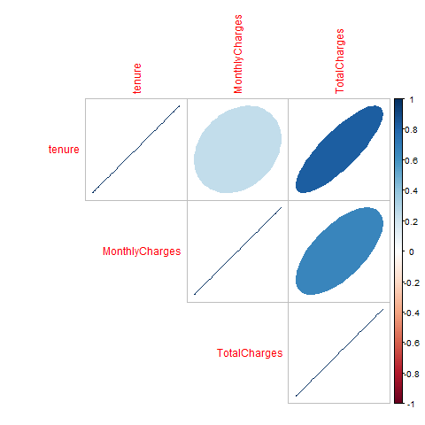

```python
%%R

corrplot(cor( Filter(is.numeric,data)),method = "ellipse",type = "upper")
```

Se aprecia correlaciones esperada entre el cargo mensual y el cargo total (65%). Una correlación significativa es la de tenure y cargo total

```python
%%R

# Numeric Variables
Num<-sapply(data,is.numeric)

Num<-as.data.frame(subset(data,select=c(Num)))

n.num <- length(Num)


all.names<-as.array(colnames(Num))

# Correlaciones
table.cor <- data.frame(Variable.1 = NA,
                        Variable.2 = NA,
                        Corr = numeric(n.num*(n.num - 1)/2))


k <- 1
for (i in 1:(n.num - 1)){
  for (j in (i + 1):n.num){
    x <- Num[,all.names[c(i, j)]]
    if (is.numeric(x[,1]) & is.numeric(x[,2])){
      x <- x[!is.na(x[,1]) & !is.na(x[,2]),]
      #cat(sprintf("cor(%s, %s) = %.2f \n", all.names[i], all.names[j], cor(x[,1], (x[,2]))))
      table.cor[k, 1] <- all.names[i]
      table.cor[k, 2] <- all.names[j]
      table.cor[k, 3] <- cor(x[,1], x[,2])
      k <- k + 1
    } else{
      next
    }
  }
}

table.cor <- table.cor[order(table.cor$Corr, decreasing = TRUE),]


rownames(table.cor) <- NULL

print(table.cor)
```

```
      Variable.1     Variable.2      Corr
1         tenure   TotalCharges 0.8249385
2 MonthlyCharges   TotalCharges 0.6511780
3         tenure MonthlyCharges 0.2478999
```

Vamos a revisar si existe relación entre la fuga y las vaiables numéricas

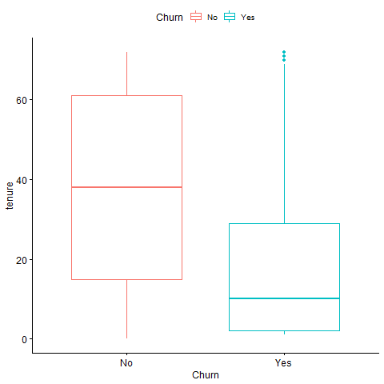

```python
%%R

ggboxplot(data, x = "Churn", y = "tenure",
          color = "Churn",
          ylab = "tenure", xlab = "Churn")
```

```python
%%R
# Compute the analysis of variance
res.aov <- aov(tenure ~ Churn, data = data)
# Summary of the analysis
summary(res.aov)
```

```
              Df  Sum Sq Mean Sq F value Pr(>F)
Churn          1  526967  526967   997.3 <2e-16 ***
Residuals   7041 3720542     528
---
Signif. codes:  0 '***' 0.001 '**' 0.01 '*' 0.05 '.' 0.1 ' ' 1
```

Los clientes que se dieron a la fuga tenían menos meses con la compañía. En el análisis ANOVA se comprueba estadísticamente.

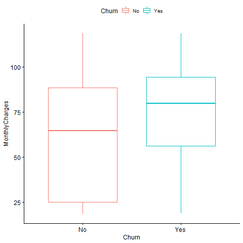

```python
%%R

ggboxplot(data, x = "Churn", y = "MonthlyCharges",
          color = "Churn",
          ylab = "MonthlyCharges", xlab = "Churn")
```

```python
%%R
# Compute the analysis of variance
res.aov <- aov(MonthlyCharges ~ Churn, data = data)
# Summary of the analysis
summary(res.aov)
```

```
              Df  Sum Sq Mean Sq F value Pr(>F)
Churn          1  238374  238374   273.5 <2e-16 ***
Residuals   7041 6137530     872
---
Signif. codes:  0 '***' 0.001 '**' 0.01 '*' 0.05 '.' 0.1 ' ' 1
```

Los clientes que fugaron tenían mayores niveles de cargo fijo

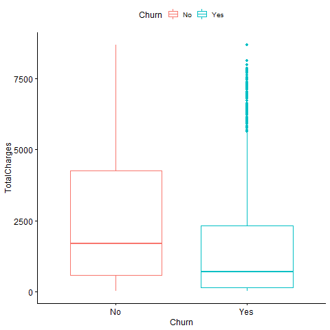

```python
%%R

ggboxplot(data, x = "Churn", y = "TotalCharges",
          color = "Churn",
          ylab = "TotalCharges", xlab = "Churn")
```

```python
%%R
# Compute the analysis of variance
res.aov <- aov(TotalCharges ~ Churn, data = data)
# Summary of the analysis
summary(res.aov)
```

```
              Df    Sum Sq   Mean Sq F value Pr(>F)
Churn          1 1.434e+09 1.434e+09   290.9 <2e-16 ***
Residuals   7041 3.471e+10 4.930e+06
---
Signif. codes:  0 '***' 0.001 '**' 0.01 '*' 0.05 '.' 0.1 ' ' 1
```

```python
%%R
set.seed(123)
# Creo la variable aleatoria
data$aleatorio<-runif(nrow(data))
data$aleatorio2<-runif(nrow(data))
```

```python
%%R

data_temp<-data
target<-data_temp$Churn
data_temp <- subset( data_temp, select = - Churn )
```

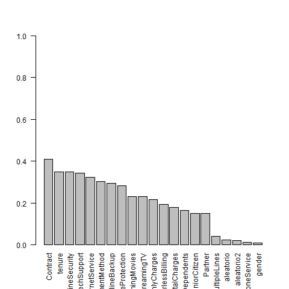

```python
%%R

graficoVcramer(data_temp,target)
```

En base a la VCramer descartaría sólo PhoneService y gender que tiene influencia por debajo de las 2 aleatorias

```python
%%R


rm(data_temp)
```

### Análisis a través de WOE - weight of evidence

```python
%%R

data_temp<-data

data_temp$Churn<-ifelse(data_temp$Churn=="Yes",1,0)
```

```python
%%R
# factor and categorical variables using methods including tree-like segmentation or chi-square merge
bins <- woebin(data_temp, "Churn", print_step = 0)
```

```
[INFO] creating woe binning ...
```

[output not shown]

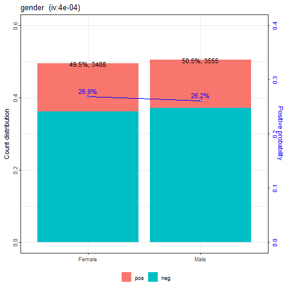

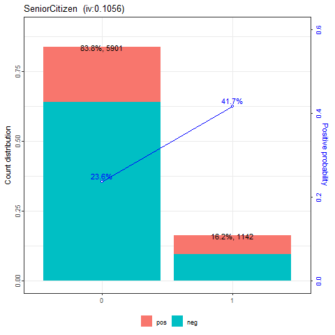

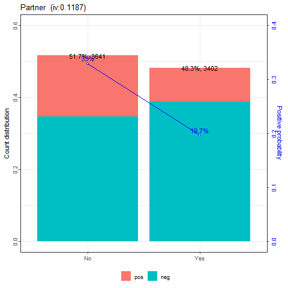

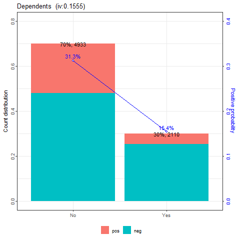

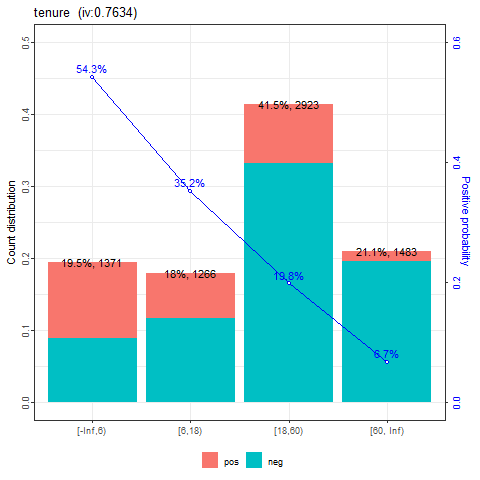

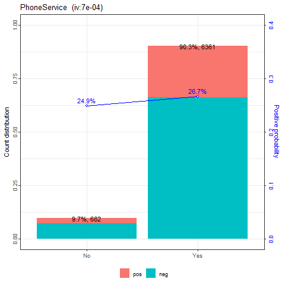

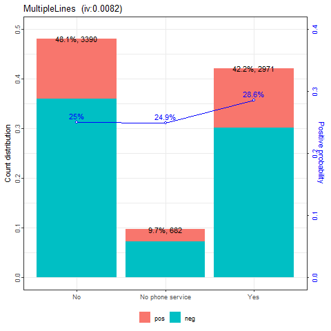

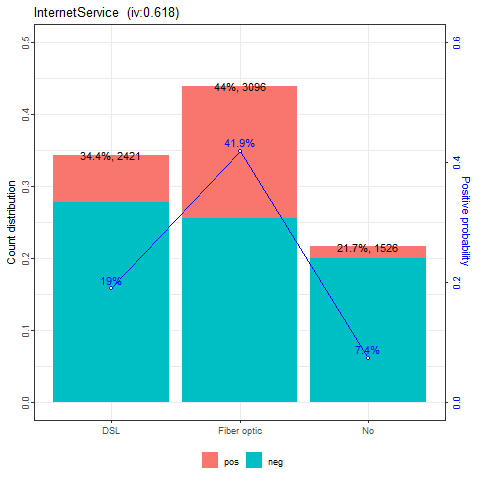

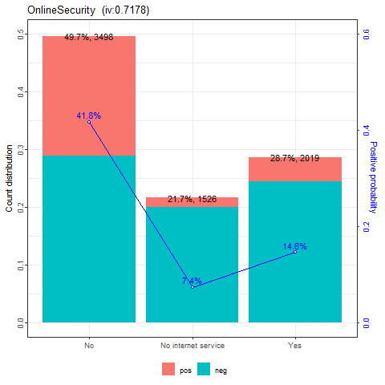

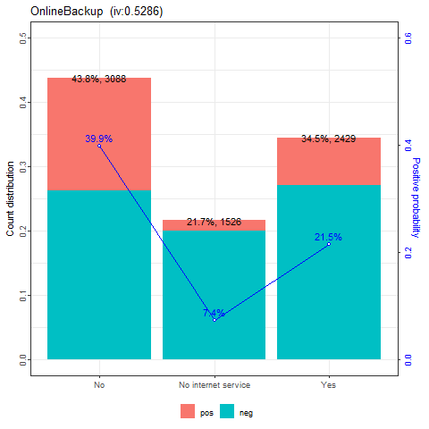

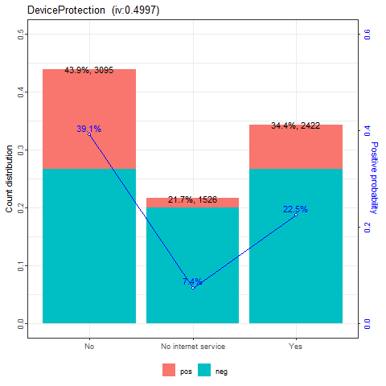

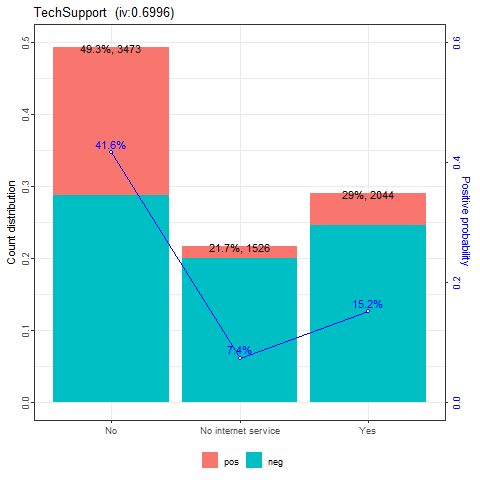

[9 more figures not shown]

```python
%%R

woebin_plot(bins)
```

Tal como se esperaba la variable género aporta poco information value.

La varaible SeniroCitizane sí aporta valor ya que existe diferencias significativas

La varaible Partner sí aporta valor ya que existe diferencias significativas

La varaible Dependents sí aporta valor ya que existe diferencias significativas

La variable tenure muestra una relación inversa con la tasa de fuga. Los rango de 0 a 18 meses son los que hacen que la tasa sea más alta. Se debe hacer esfuerzos por aumentar la tenencia en meses con alguna campaña de incentivo a los que están por terminar los 18 o quizá el resultado es consecuencia de que los que tienen más meeses con nosotros han "sobrevivido"

Tal como se esperaba la variable PhoneService aporta poco information value.

La varaible de tenencia de varios servicios de teléfono parece no ser muy relevante

La tenencia de internet parece tener muy alta relevancia, sobre todo en los que tienen fibra. Quizá un proyecto para mejorar el producto o servicio postventa en internet sea beneficio no sólo en dicho producto si no también en la telefonía celular lo que puede llevar a aumentar los presupuesto hasta ese momento invertidos.

Los cientes que tienen seguridad online tienen tasas más bajas de fuga, quizá convenga hacer más accesible el producto a la mayoría de clientes con internet

El tener onlinebackup si bien da menores tasas de fuga que no tenerlo, su tasa es ligeramente menor al de la población (26%). igual entre os clientes con internet serviría hacerlo más accesible.

Con la variables: DeviceProtection, TechSupport , StreamingTV y StreamingMovie conviene lo mismo que con OnlineBackup

La varaible Contract demuestra que no tener contrato es una posibilidad al cliente para que se vaya. Debe ofrecerse hacer contratos de más de 1 año, lo usual es ofrecer equipos celulares pero también podría ser ofrecer repetidores de señal que tienen poca subvención económica.

Los clientes con PaperlessBilling tienen mayor tasa de fuga. Habrái que averiguar por qué , quizá no les llega su recibo digital.

Los clientes que pagan por Elecrtonic check al parecer están teniendo problemas con el servicio y están fugando mucho más.Urge ayudarlos o darles facilidades de pago que sean menos costosas que con otros medios pero que sí funcionen.

Existen dos rangos de cargos fijos que dene preocuparnos más: de 26 a 56 y de 68 a 106. Habría que revisar qué ofrecen dichos planes. En el plan de 68 a 106 están casi la mitad de los clientes.

Los clientes con cargo total alto son lo que experimentan menores tasas de fuga. Casi la mitad está en el rango de 400 a 3600. Habría que ver qué productos son pero se infiere que es el de internet que tienen que está causando problemas pero en los rangos de facturación menores.

Los IV de las variables aleatorias no llegan a 0.02 que es lo esperado en ese tipos de variables

```python
%%R

tabla_iv<-data.frame(Variable = NA,
                        iv = NA)

k<-1
for(i in bins)
{
    tabla_iv[k,1]<-unique( i$variable)
    tabla_iv[k,2]<-unique( i$total_iv)
    k<-k+1
}



#for(i in bins){print( unique( i$variable))
#               print( unique( i$total_iv))}
```

```python
%%R

tabla_iv<-as.data.frame(tabla_iv)
#tabla_iv[order(tabla_iv$iv,decreasing = T) ]
tabla_iv[order(-tabla_iv$iv),]
#tabla_iv
```

```
           Variable           iv
15         Contract 1.2385597928
5            tenure 0.7633659056
9    OnlineSecurity 0.7177771389
12      TechSupport 0.6995672949
8   InternetService 0.6179525742
10     OnlineBackup 0.5286341230
11 DeviceProtection 0.4997245050
17    PaymentMethod 0.4571089328
18   MonthlyCharges 0.4552440898
14  StreamingMovies 0.3813743120
13      StreamingTV 0.3804623299
19     TotalCharges 0.3170864410
16 PaperlessBilling 0.2030683847
4        Dependents 0.1554877150
3           Partner 0.1187285028
2     SeniorCitizen 0.1056211829
21       aleatorio2 0.0179503281
20        aleatorio 0.0092798660
7     MultipleLines 0.0082068115
6      PhoneService 0.0007448405
1            gender 0.0003804366
```

En función a los análisis hasta ahora realizados, sólo retiraría: PhoneService, gender, MultipleLines. Las varaibles aleatorias sólo sirven para comparación

```python
%%R

rm(data_temp)
```

```python
%%R

variables_elegidas<-c( 'Contract',	'tenure',	'OnlineSecurity',	'TechSupport',	'InternetService',	'OnlineBackup',	'DeviceProtection',	'PaymentMethod',	'MonthlyCharges',	'StreamingMovies',	'StreamingTV',	'TotalCharges',	'PaperlessBilling',	'Dependents',	'Partner',	'SeniorCitizen',	'aleatorio2',	'aleatorio')
data_final<-data[,variables_elegidas]
data_final$y<-data$Churn
```

```python
%%R
sapply(data_final,class)
```

```
        Contract           tenure   OnlineSecurity      TechSupport
        "factor"        "integer"         "factor"         "factor"
 InternetService     OnlineBackup DeviceProtection    PaymentMethod
        "factor"         "factor"         "factor"         "factor"
  MonthlyCharges  StreamingMovies      StreamingTV     TotalCharges
       "numeric"         "factor"         "factor"        "numeric"
PaperlessBilling       Dependents          Partner    SeniorCitizen
        "factor"         "factor"         "factor"         "factor"
      aleatorio2        aleatorio                y
       "numeric"        "numeric"         "factor"
```

```python
%%R

listconti<-c("tenure", "MonthlyCharges", "TotalCharges", "aleatorio2",   "aleatorio")
listclass<-c('Contract',	'OnlineSecurity',	'TechSupport',	'InternetService',	'OnlineBackup',	'DeviceProtection',	'PaymentMethod','StreamingMovies',	'StreamingTV',	'PaperlessBilling',	'Dependents',	'Partner',	'SeniorCitizen')
vardep<-c("y")
```

```python
%%R

data_final<- dummy.data.frame(data_final, names=listclass, sep = "_")
```

```python
%%R
# Estandarizar las variables continuas

# Calculo medias y dtipica de datos y estandarizo (solo las continuas)

means <-apply(data_final[,listconti],2,mean)
sds<-sapply(data_final[,listconti],sd)


# Estandarizo solo las continuas y uno con las categoricas

Datos3<-scale(data_final[,listconti], center = means, scale = sds)
# Datos3 son solo las continuas de data_final
numerocont<-which(colnames(data_final)%in%listconti)
# numerocont son las columnas que corresponden a las continuas de data_final
Datosfin<-cbind(Datos3,data_final[,-numerocont])
# Datosfin une Datos3 con solo las dummies de data_final y la dependiente
```

```python
%%R
head(Datosfin)
```

```
       tenure MonthlyCharges TotalCharges   aleatorio2  aleatorio
1 -1.27735389     -1.1602405   -0.9942908 -1.647210106 -0.7356328
2  0.06632271     -0.2596105   -0.1734928 -1.014658823  1.0082494
3 -1.23663642     -0.3626346   -0.9597314  0.471967063 -0.3128356
4  0.51421491     -0.7464825   -0.1950097  1.420166559  1.3381035
5 -1.23663642      0.1973512   -0.9405317 -0.008333458  1.5381840
6 -0.99233158      1.1594634   -0.6453198 -1.118024663 -1.5785186
  Contract_Month-to-month Contract_One year Contract_Two year OnlineSecurity_No
1                       1                 0                 0                 1
2                       0                 1                 0                 0
3                       1                 0                 0                 0
4                       0                 1                 0                 0
5                       1                 0                 0                 1
6                       1                 0                 0                 1
  OnlineSecurity_No internet service OnlineSecurity_Yes TechSupport_No
```

[output cut: 76 more lines]

```python
%%R

Datosfin$y<-ifelse(Datosfin$y=="Yes",1,0)
```

```python
%%R

table(Datosfin$y)
```

```
   0    1
5174 1869
```

Selección de variables StepAIC

```python
%%R

# SelecciÃ³n de variables
full<-glm(factor(y)~.,data=Datosfin,family = binomial(link="logit"))
null<-glm(factor(y)~1,data=Datosfin,family = binomial(link="logit"))



seleccion<-stepAIC(null,scope=list(upper=full),direction="both")
```

```
Start:  AIC=8152.15
factor(y) ~ 1

                                            Df Deviance    AIC
+ `Contract_Month-to-month`                  1   6855.8 6859.8
+ tenure                                     1   7191.9 7195.9
+ OnlineSecurity_No                          1   7285.3 7289.3
+ `Contract_Two year`                        1   7296.9 7300.9
+ TechSupport_No                             1   7315.2 7319.2
+ `InternetService_Fiber optic`              1   7476.7 7480.7
+ `PaymentMethod_Electronic check`           1   7531.5 7535.5
+ OnlineBackup_No                            1   7643.1 7647.1
+ DeviceProtection_No                        1   7700.7 7704.7
+ `OnlineSecurity_No internet service`       1   7708.3 7712.3
+ `TechSupport_No internet service`          1   7708.3 7712.3
+ InternetService_No                         1   7708.3 7712.3
+ `OnlineBackup_No internet service`         1   7708.3 7712.3
+ `DeviceProtection_No internet service`     1   7708.3 7712.3
+ `StreamingMovies_No internet service`      1   7708.3 7712.3
+ `StreamingTV_No internet service`          1   7708.3 7712.3
+ TotalCharges                               1   7841.0 7845.0
+ MonthlyCharges                             1   7878.2 7882.2
+ PaperlessBilling_No                        1   7879.8 7883.8
+ PaperlessBilling_Yes                       1   7879.8 7883.8
+ `Contract_One year`                        1   7895.7 7899.7
+ OnlineSecurity_Yes                         1   7926.4 7930.4
+ TechSupport_Yes                            1   7944.4 7948.4
+ Dependents_No                              1   7946.4 7950.4
+ Dependents_Yes                             1   7946.4 7950.4
+ Partner_No                                 1   7988.8 7992.8
+ Partner_Yes                                1   7988.8 7992.8
+ SeniorCitizen_0                            1   8001.2 8005.2
+ SeniorCitizen_1                            1   8001.2 8005.2
+ `PaymentMethod_Credit card (automatic)`    1   8011.6 8015.6
+ StreamingMovies_No                         1   8031.2 8035.2
+ StreamingTV_No                             1   8034.6 8038.6
+ InternetService_DSL                        1   8037.3 8041.3
+ `PaymentMethod_Bank transfer (automatic)`  1   8044.9 8048.9
+ `PaymentMethod_Mailed check`               1   8087.9 8091.9
+ OnlineBackup_Yes                           1   8101.4 8105.4
```

[output cut: 807 more lines]

```
- Dependents_No                              1   5854.2 5886.2
- SeniorCitizen_0                            1   5858.0 5890.0
- `OnlineSecurity_No internet service`       1   5859.6 5891.6
- TechSupport_No                             1   5861.8 5893.8
- MonthlyCharges                             1   5862.6 5894.6
- OnlineSecurity_No                          1   5863.8 5895.8
- StreamingTV_Yes                            1   5867.0 5899.0
- `Contract_One year`                        1   5868.0 5900.0
- StreamingMovies_Yes                        1   5869.2 5901.2
- TotalCharges                               1   5872.6 5904.6
- PaperlessBilling_No                        1   5873.0 5905.0
- `PaymentMethod_Electronic check`           1   5877.0 5909.0
- `InternetService_Fiber optic`              1   5895.3 5927.3
- `Contract_Month-to-month`                  1   5928.1 5960.1
- tenure                                     1   5956.5 5988.5
```

```python
%%R

summary(seleccion)
```

```
Call:
glm(formula = factor(y) ~ `Contract_Month-to-month` + `InternetService_Fiber optic` +
    tenure + OnlineSecurity_No + `PaymentMethod_Electronic check` +
    StreamingMovies_Yes + TechSupport_No + PaperlessBilling_No +
    TotalCharges + `Contract_One year` + SeniorCitizen_0 + StreamingTV_Yes +
    MonthlyCharges + `OnlineSecurity_No internet service` + Dependents_No +
    aleatorio, family = binomial(link = "logit"), data = Datosfin)

Deviance Residuals:
    Min       1Q   Median       3Q      Max
-1.8731  -0.6823  -0.2867   0.7387   3.3620

Coefficients:
                                     Estimate Std. Error z value Pr(>|z|)
(Intercept)                          -3.56176    0.21629 -16.467  < 2e-16 ***
`Contract_Month-to-month`             1.41145    0.17573   8.032 9.61e-16 ***
`InternetService_Fiber optic`         1.21235    0.18207   6.659 2.76e-11 ***
tenure                               -1.39869    0.14587  -9.589  < 2e-16 ***
OnlineSecurity_No                     0.32496    0.08831   3.680 0.000233 ***
`PaymentMethod_Electronic check`      0.36000    0.06907   5.212 1.87e-07 ***
StreamingMovies_Yes                   0.40726    0.09333   4.363 1.28e-05 ***
TechSupport_No                        0.30496    0.08957   3.405 0.000663 ***
PaperlessBilling_No                  -0.35399    0.07418  -4.772 1.83e-06 ***
TotalCharges                          0.72033    0.15500   4.647 3.37e-06 ***
`Contract_One year`                   0.71580    0.17659   4.053 5.05e-05 ***
SeniorCitizen_0                      -0.23494    0.08352  -2.813 0.004911 **
StreamingTV_Yes                       0.38784    0.09440   4.108 3.99e-05 ***
MonthlyCharges                       -0.55156    0.15613  -3.533 0.000411 ***
`OnlineSecurity_No internet service` -0.68220    0.22124  -3.083 0.002046 **
Dependents_No                         0.16448    0.08126   2.024 0.042963 *
aleatorio                            -0.04826    0.03235  -1.492 0.135719
---
Signif. codes:  0 '***' 0.001 '**' 0.01 '*' 0.05 '.' 0.1 ' ' 1

(Dispersion parameter for binomial family taken to be 1)

    Null deviance: 8150.1  on 7042  degrees of freedom
Residual deviance: 5850.1  on 7026  degrees of freedom
AIC: 5884.1

Number of Fisher Scoring iterations: 6
```

Se utilizó el modelo a través de Step Wise con criterio AIC para la selección de variables en conjunto.

La variable aleatorio es no significativa (p-vale alto) que era lo esperado

La variable Dependents es poso significativa y podría pensar en retirarla si quiero un modelo menos complejo.

Las variables que influyen de forma negativa (es decir al aumentar ellas restan probabilidad de fuga) son: tenure, PaperlessBilling_No,SeniorCitizen_0 ,MonthlyCharges ,`OnlineSecurity_No internet service`

Observar que `OnlineSecurity_No internet service` contiene la presencia o no de internet que como habíamos visto en el análisis univariante , la no presencia implica baja tasas de fuga.

Observar también que en MonthlyCharges la realción no es lineal pero aquí se habría tomado el grupo mas grande mencionado antes.Quizá un modelo no lineal utilice mejor esta variable

Tener presente que con la variable TotalCharges habrá que hacer un análisis ya que le coeficiente es positivo pero el análisis univariante nos hubiera lelvado a pensar que sería negativo, aunque se mencionó que los valores altos tendrían relación a la presencia de internte que es la que dispara la tasa de fuga y hay predominancia por el rango de 400 a 3600 . También quizá un modelo no lineal utilice mejor esta variable

```python
%%R
# Para ver los efectos escogidos
dput(names(seleccion$coefficients))
```

```
c("(Intercept)", "`Contract_Month-to-month`", "`InternetService_Fiber optic`",
"tenure", "OnlineSecurity_No", "`PaymentMethod_Electronic check`",
"StreamingMovies_Yes", "TechSupport_No", "PaperlessBilling_No",
"TotalCharges", "`Contract_One year`", "SeniorCitizen_0", "StreamingTV_Yes",
"MonthlyCharges", "`OnlineSecurity_No internet service`", "Dependents_No",
"aleatorio")
```

```python
%%R
# Esto si se quiere en versiÃ³n formula
formula(seleccion)
```

```
factor(y) ~ `Contract_Month-to-month` + `InternetService_Fiber optic` +
    tenure + OnlineSecurity_No + `PaymentMethod_Electronic check` +
    StreamingMovies_Yes + TechSupport_No + PaperlessBilling_No +
    TotalCharges + `Contract_One year` + SeniorCitizen_0 + StreamingTV_Yes +
    MonthlyCharges + `OnlineSecurity_No internet service` + Dependents_No +
    aleatorio
```

Veamos cómo le va a un modelo simple no lineal

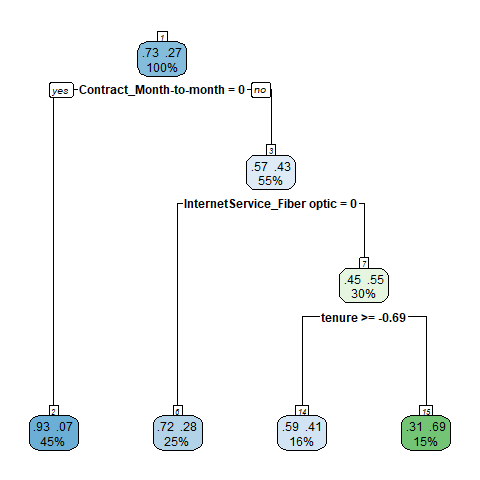

```python
%%R
#Veamos el análisis que podamos sacar con un árbol

arbol1 <- rpart(factor(y) ~ `Contract_Month-to-month` + `InternetService_Fiber optic` +
    tenure + OnlineSecurity_No + `PaymentMethod_Electronic check` +
    StreamingMovies_Yes + TechSupport_No + PaperlessBilling_No +
    TotalCharges + `Contract_One year` + SeniorCitizen_0 + StreamingTV_Yes +
    MonthlyCharges + `OnlineSecurity_No internet service` , data = Datosfin,
 minbucket =10,method = "class",parms=list(split="gini"))

rpart.plot(arbol1,extra=105,nn=TRUE)
```

```python
%%R
#funcion para Stepwise pero repetido para distintas semillas, con criterios AIC y BIC para seleccionar

steprepetidobinaria<- function(data=data,vardep="vardep",
  listconti="listconti",
 sinicio=12345,sfinal=12355,porcen=0.8,criterio="BIC")
 {

library(MASS)
library(dplyr)

resultados<-data.frame(c())
data<-data[,c(listconti,vardep)]
formu1<-formula(paste("factor(",vardep,")~.",sep=""))
formu2<-formula(paste("factor(",vardep,")~1",sep=""))
listamodelos<-list()

for (semilla in sinicio:sfinal)
{
set.seed(semilla)
sample <- sample.int(n = nrow(data),
 size = floor(porcen*nrow(data)), replace = F)

train <- data[sample, ]
test  <- data[-sample, ]


full<-glm(formu1,data=train,family = binomial(link="logit"))
null<-glm(formu2,data=train,family = binomial(link="logit"))


if  (criterio=='AIC')
  {
  selec1<-stepAIC(null,scope=list(upper=full),
   direction="both",family = binomial(link="logit"),trace=FALSE)
  }
else   if  (criterio=='BIC')
  {
 k1=log(nrow(train))
 selec1<-stepAIC(null,scope=list(upper=full),
  direction="both",family = binomial(link="logit"),k=k1,trace=FALSE)
  }

vec<-(names(selec1[[1]]))

if (length(vec)!=1)

{
# CAMBIOS

cosa<-as.data.frame(table(vec))
cosa<-as.data.frame(t(cosa))
colnames(cosa)<-vec

# 1) creo un vector con todas las variables input y ceros
# 2) voy aÃ±adiendo

cosa<-cosa[2,,drop=FALSE]
cosa<-cosa[,-(1),drop=FALSE]
cosa<- data.frame(lapply(cosa, function(x) as.numeric(as.character(x))))
cosa$id<-semilla
}

if (length(vec)==1)
{
cosa<-data.frame()
cosa[1,"id"]<-semilla
cosa$id<-as.integer(cosa$id)
}
vectormodelo<-list(names(cosa),semilla)
listamodelos<-append(listamodelos,vectormodelo)

if (semilla==sinicio)
{
listamod<-cosa
}

else if (semilla!=sinicio)
{
 listamod<-suppressMessages(full_join(cosa,listamod,by = NULL, copy =TRUE))
}

}

listamod[is.na(listamod)] <- 0

nom<-names(listamod)
listamod$modelo<-""
for (i in 1:nrow(listamod))
{
 listamod[i,c("modelo")]<-""
 listamod[i,c("contador")]=0

  for (vari in nom)
  {
   if (listamod[i,vari]==1)
   {
   listamod[i,c("modelo")]<-paste(listamod[i,c("modelo")],vari,collapse="",sep="+")
   listamod[i,c("contador")]=listamod[i,c("contador")]+1
   }

   }

}

listamod$modelo<-substring(listamod$modelo, 2)

tablamod<-as.data.frame(table(listamod$modelo))
names(tablamod)<-c("modelo","Freq")

tablamod<-tablamod[order(-tablamod$Freq,tablamod$modelo),]

nuevo<-listamod[,c("modelo","id","contador")]

uni<-full_join(tablamod,nuevo,by ="modelo", copy =TRUE)

uni= uni[!duplicated(uni$modelo),]
uni$semilla<-semilla

li1<-list()
# str(listamodelos)
for (i in 1:nrow(uni))
{
 for (j in 1:length(listamodelos))
 {
    if (uni[i,c("id")]==listamodelos[j][[1]])
  {
   k<-as.vector(listamodelos[j-1][[1]])
   length(k)<-length(k)-1
   li1<-c(li1,list(k))
   j=length(listamodelos)
  }
 }

}

 uni$semilla<-NULL
 uni$id<-NULL
 return(list(uni,li1))

}
```

```python
%%R

data_step<-Datosfin

dput(names(Datosfin))
```

```
c("tenure", "MonthlyCharges", "TotalCharges", "aleatorio2", "aleatorio",
"Contract_Month-to-month", "Contract_One year", "Contract_Two year",
"OnlineSecurity_No", "OnlineSecurity_No internet service", "OnlineSecurity_Yes",
"TechSupport_No", "TechSupport_No internet service", "TechSupport_Yes",
"InternetService_DSL", "InternetService_Fiber optic", "InternetService_No",
"OnlineBackup_No", "OnlineBackup_No internet service", "OnlineBackup_Yes",
"DeviceProtection_No", "DeviceProtection_No internet service",
"DeviceProtection_Yes", "PaymentMethod_Bank transfer (automatic)",
"PaymentMethod_Credit card (automatic)", "PaymentMethod_Electronic check",
"PaymentMethod_Mailed check", "StreamingMovies_No", "StreamingMovies_No internet service",
"StreamingMovies_Yes", "StreamingTV_No", "StreamingTV_No internet service",
"StreamingTV_Yes", "PaperlessBilling_No", "PaperlessBilling_Yes",
"Dependents_No", "Dependents_Yes", "Partner_No", "Partner_Yes",
"SeniorCitizen_0", "SeniorCitizen_1", "y")
```

```python
%%R

listaconti<-dput(names(Datosfin))

listaconti<-listaconti[!(listaconti %in% c("y"))]
```

```
c("tenure", "MonthlyCharges", "TotalCharges", "aleatorio2", "aleatorio",
"Contract_Month-to-month", "Contract_One year", "Contract_Two year",
"OnlineSecurity_No", "OnlineSecurity_No internet service", "OnlineSecurity_Yes",
"TechSupport_No", "TechSupport_No internet service", "TechSupport_Yes",
"InternetService_DSL", "InternetService_Fiber optic", "InternetService_No",
"OnlineBackup_No", "OnlineBackup_No internet service", "OnlineBackup_Yes",
"DeviceProtection_No", "DeviceProtection_No internet service",
"DeviceProtection_Yes", "PaymentMethod_Bank transfer (automatic)",
"PaymentMethod_Credit card (automatic)", "PaymentMethod_Electronic check",
"PaymentMethod_Mailed check", "StreamingMovies_No", "StreamingMovies_No internet service",
"StreamingMovies_Yes", "StreamingTV_No", "StreamingTV_No internet service",
"StreamingTV_Yes", "PaperlessBilling_No", "PaperlessBilling_Yes",
"Dependents_No", "Dependents_Yes", "Partner_No", "Partner_Yes",
"SeniorCitizen_0", "SeniorCitizen_1", "y")
```

```python
%%R

lista<-steprepetidobinaria(data=Datosfin,
 vardep=vardep,listconti=listconti,sinicio=12345,
 sfinal=12395,porcen=0.8,criterio="AIC")
```

```python
%%R

tabla<-lista[[1]]
dput(lista[[2]][[1]])
dput(lista[[2]][[2]])
tabla
```

```
c("tenure", "MonthlyCharges", "TotalCharges")
c("tenure", "MonthlyCharges")
                                         modelo Freq contador
1            tenure+MonthlyCharges+TotalCharges   24        3
25                        tenure+MonthlyCharges   11        2
36              tenure+MonthlyCharges+aleatorio    8        3
44 tenure+MonthlyCharges+aleatorio+TotalCharges    7        4
51             tenure+MonthlyCharges+aleatorio2    1        3
```

LA primera selección de variables se repite con más frecuencia

```python
%%R


mod2<-c("tenure", "MonthlyCharges", "TotalCharges")
```

```python
%%R

lista2<-steprepetidobinaria(data=Datosfin,
 vardep=vardep,listconti=listconti,sinicio=12345,
 sfinal=12395,porcen=0.8,criterio="BIC")
```

```python
%%R

tabla2<-lista2[[1]]
dput(lista2[[2]][[1]])

tabla2
```

```
c("tenure", "MonthlyCharges")
                 modelo Freq contador
1 tenure+MonthlyCharges   51        2
```

Esta selección ya está contenida en la anterior y son muy pocas las variables ahora, la descartaría

```python
%%R

mod1<-c("Contract_Month-to-month", "InternetService_Fiber optic", "tenure", "OnlineSecurity_No", "PaymentMethod_Electronic check", "StreamingMovies_Yes", "TechSupport_No", "PaperlessBilling_No", "TotalCharges", "Contract_One year","SeniorCitizen_0","StreamingTV_Yes","MonthlyCharges","OnlineSecurity_No internet service")
```

```python
%%R

colnames(Datosfin)
```

```
 [1] "tenure"
 [2] "MonthlyCharges"
 [3] "TotalCharges"
 [4] "aleatorio2"
 [5] "aleatorio"
 [6] "Contract_Month-to-month"
 [7] "Contract_One year"
 [8] "Contract_Two year"
 [9] "OnlineSecurity_No"
[10] "OnlineSecurity_No internet service"
[11] "OnlineSecurity_Yes"
[12] "TechSupport_No"
[13] "TechSupport_No internet service"
[14] "TechSupport_Yes"
[15] "InternetService_DSL"
```

[output cut: 27 more lines]

```python
%%R

mod<-c(mod1,mod2)

mod<-unique(mod)

print(mod)
```

```
 [1] "Contract_Month-to-month"            "InternetService_Fiber optic"
 [3] "tenure"                             "OnlineSecurity_No"
 [5] "PaymentMethod_Electronic check"     "StreamingMovies_Yes"
 [7] "TechSupport_No"                     "PaperlessBilling_No"
 [9] "TotalCharges"                       "Contract_One year"
[11] "SeniorCitizen_0"                    "StreamingTV_Yes"
[13] "MonthlyCharges"                     "OnlineSecurity_No internet service"
```

```python
%%R

Datosfin_sel<-Datosfin[,mod]
Datosfin_sel$y<-Datosfin$y
```

```python
%%R

table(Datosfin_sel$y)
```

```
   0    1
5174 1869
```

```python
%%R

#Hago la particiÃ³n
set.seed(1234)
trainIndex <- createDataPartition(Datosfin_sel$y, p=0.8, list=FALSE)
Datosfin_sel_p_train <- Datosfin_sel[trainIndex,]
Datosfin_sel_p_test <- Datosfin_sel[-trainIndex, ]

print(prop.table(table(Datosfin_sel_p_train$y)))

print(nrow(Datosfin_sel_p_train))
```

```
       0        1
0.733984 0.266016
[1] 5635
```

```python
%%R


print(prop.table(table(Datosfin_sel_p_test$y)))

print(nrow(Datosfin_sel_p_test))
```

```
        0         1
0.7372159 0.2627841
[1] 1408
```

```python
%%R

colMeans(Datosfin_sel_p_train)
```

```
           Contract_Month-to-month        InternetService_Fiber optic
                       0.553327418                        0.440106477
                            tenure                  OnlineSecurity_No
                      -0.002980090                        0.500798580
    PaymentMethod_Electronic check                StreamingMovies_Yes
                       0.333984028                        0.392369122
                    TechSupport_No                PaperlessBilling_No
                       0.486779059                        0.409760426
                      TotalCharges                  Contract_One year
                      -0.003767172                        0.205856256
                   SeniorCitizen_0                    StreamingTV_Yes
                       0.837267081                        0.385803017
                    MonthlyCharges OnlineSecurity_No internet service
                       0.003408067                        0.215971606
                                 y
                       0.266015972
```

```python
%%R

colMeans(Datosfin_sel_p_test)
```

```
           Contract_Month-to-month        InternetService_Fiber optic
                        0.53764205                         0.43750000
                            tenure                  OnlineSecurity_No
                        0.01192671                         0.48011364
    PaymentMethod_Electronic check                StreamingMovies_Yes
                        0.34303977                         0.37002841
                    TechSupport_No                PaperlessBilling_No
                        0.51846591                         0.39985795
                      TotalCharges                  Contract_One year
                        0.01507672                         0.22230114
                   SeniorCitizen_0                    StreamingTV_Yes
                        0.84019886                         0.37855114
                    MonthlyCharges OnlineSecurity_No internet service
                       -0.01363953                         0.21946023
                                 y
                        0.26278409
```

```python
%%R

head(Datosfin_sel_p_train)
```

```
  Contract_Month-to-month InternetService_Fiber optic     tenure
1                       1                           0 -1.2773539
3                       1                           0 -1.2366364
4                       0                           0  0.5142149
5                       1                           1 -1.2366364
6                       1                           1 -0.9923316
7                       1                           1 -0.4222870
  OnlineSecurity_No PaymentMethod_Electronic check StreamingMovies_Yes
1                 1                              1                   0
3                 0                              0                   0
4                 0                              0                   0
5                 1                              1                   0
6                 1                              1                   1
7                 1                              0                   0
  TechSupport_No PaperlessBilling_No TotalCharges Contract_One year
```

[output cut: 20 more lines]

```python
Datosfin_sel_p = %Rget Datosfin_sel_p_train

mod1 = %Rget mod1
mod2 = %Rget mod2
```

```python
Datosfin_sel_p.head()
```

|  | Contract_Month-to-month | InternetService_Fiber optic | tenure | OnlineSecurity_No | PaymentMethod_Electronic check | StreamingMovies_Yes | TechSupport_No | PaperlessBilling_No | TotalCharges | Contract_One year | SeniorCitizen_0 | StreamingTV_Yes | MonthlyCharges | OnlineSecurity_No internet service | y |
| --- | --- | --- | --- | --- | --- | --- | --- | --- | --- | --- | --- | --- | --- | --- | --- |
| 1 | 1 | 0 | -1.277354 | 1 | 1 | 0 | 1 | 0 | -0.994291 | 0 | 1 | 0 | -1.160241 | 0 | 0.0 |
| 3 | 1 | 0 | -1.236636 | 0 | 0 | 0 | 1 | 0 | -0.959731 | 0 | 1 | 0 | -0.362635 | 0 | 1.0 |
| 4 | 0 | 0 | 0.514215 | 0 | 0 | 0 | 0 | 1 | -0.195010 | 1 | 1 | 0 | -0.746482 | 0 | 0.0 |
| 5 | 1 | 1 | -1.236636 | 1 | 1 | 0 | 1 | 0 | -0.940532 | 0 | 1 | 0 | 0.197351 | 0 | 1.0 |
| 6 | 1 | 1 | -0.992332 | 1 | 1 | 1 | 1 | 0 | -0.645320 | 0 | 1 | 1 | 1.159463 | 0 | 1.0 |

```python
Datosfin_sel_p.dtypes
```

```
Contract_Month-to-month                 int32
InternetService_Fiber optic             int32
tenure                                float64
OnlineSecurity_No                       int32
PaymentMethod_Electronic check          int32
StreamingMovies_Yes                     int32
TechSupport_No                          int32
PaperlessBilling_No                     int32
TotalCharges                          float64
Contract_One year                       int32
SeniorCitizen_0                         int32
StreamingTV_Yes                         int32
MonthlyCharges                        float64
OnlineSecurity_No internet service      int32
y                                     float64
dtype: object
```

```python
print(mod2)
```

```
[1] "tenure"         "MonthlyCharges" "TotalCharges"
```

```python
print(mod1)
```

```
 [1] "Contract_Month-to-month"            "InternetService_Fiber optic"
 [3] "tenure"                             "OnlineSecurity_No"
 [5] "PaymentMethod_Electronic check"     "StreamingMovies_Yes"
 [7] "TechSupport_No"                     "PaperlessBilling_No"
 [9] "TotalCharges"                       "Contract_One year"
[11] "SeniorCitizen_0"                    "StreamingTV_Yes"
[13] "MonthlyCharges"                     "OnlineSecurity_No internet service"
```

### Modelado

Utilizaremos una libraría de automl de reciente creacion 'Pycaret' para tener una línea base para el tuneo de los modelos

```python
Datosfin_sel_p_mod1=Datosfin_sel_p[mod1]
```

```python
Datosfin_sel_p_mod1.loc[:,'y']=Datosfin_sel_p.loc[:,'y']
```

```python
Datosfin_sel_p_mod1.loc[:,'y']=Datosfin_sel_p_mod1.loc[:,'y'].astype('int')
```

```python
Datosfin_sel_p_mod1.head()
```

|  | Contract_Month-to-month | InternetService_Fiber optic | tenure | OnlineSecurity_No | PaymentMethod_Electronic check | StreamingMovies_Yes | TechSupport_No | PaperlessBilling_No | TotalCharges | Contract_One year | SeniorCitizen_0 | StreamingTV_Yes | MonthlyCharges | OnlineSecurity_No internet service | y |
| --- | --- | --- | --- | --- | --- | --- | --- | --- | --- | --- | --- | --- | --- | --- | --- |
| 1 | 1 | 0 | -1.277354 | 1 | 1 | 0 | 1 | 0 | -0.994291 | 0 | 1 | 0 | -1.160241 | 0 | 0 |
| 3 | 1 | 0 | -1.236636 | 0 | 0 | 0 | 1 | 0 | -0.959731 | 0 | 1 | 0 | -0.362635 | 0 | 1 |
| 4 | 0 | 0 | 0.514215 | 0 | 0 | 0 | 0 | 1 | -0.195010 | 1 | 1 | 0 | -0.746482 | 0 | 0 |
| 5 | 1 | 1 | -1.236636 | 1 | 1 | 0 | 1 | 0 | -0.940532 | 0 | 1 | 0 | 0.197351 | 0 | 1 |
| 6 | 1 | 1 | -0.992332 | 1 | 1 | 1 | 1 | 0 | -0.645320 | 0 | 1 | 1 | 1.159463 | 0 | 1 |

```python
!pip install --user pycaret
```

```python
pip install -U scikit-learn
```

```python
pip list
```

[output not shown]

[output cut: 75 more lines]

[output not shown]

```python
pip install sklearn
```

```python
from pycaret.classification import *
exp_clf101 = setup(data = Datosfin_sel_p_mod1, target = 'y', session_id=123,
                   numeric_features = ['Contract_Month-to-month',	'InternetService_Fiber optic',	'tenure',	'OnlineSecurity_No',	'PaymentMethod_Electronic check',	'StreamingMovies_Yes',	'TechSupport_No',	'PaperlessBilling_No',	'TotalCharges',	'Contract_One year',	'SeniorCitizen_0',	'StreamingTV_Yes',	'MonthlyCharges',	'OnlineSecurity_No internet service']   )
```

|  | Description | Value |
| --- | --- | --- |
| 0 | Session id | 123 |
| 1 | Target | y |
| 2 | Target type | Binary |
| 3 | Original data shape | (5635, 15) |
| 4 | Transformed data shape | (5635, 15) |
| 5 | Transformed train set shape | (3944, 15) |
| 6 | Transformed test set shape | (1691, 15) |
| 7 | Numeric features | 14 |
| 8 | Preprocess | True |
| 9 | Imputation type | simple |
| 10 | Numeric imputation | mean |
| 11 | Categorical imputation | mode |
| 12 | Fold Generator | StratifiedKFold |
| 13 | Fold Number | 10 |
| 14 | CPU Jobs | -1 |
| 15 | Use GPU | False |
| 16 | Log Experiment | False |
| 17 | Experiment Name | clf-default-name |
| 18 | USI | 18c0 |

```python
best_model = compare_models(sort = 'AUC',fold = 10, exclude = ['catboost'])
```

|  | Model | Accuracy | AUC | Recall | Prec. | F1 | Kappa | MCC | TT (Sec) |
| --- | --- | --- | --- | --- | --- | --- | --- | --- | --- |
| lr | Logistic Regression | 0.8053 | 0.8461 | 0.5586 | 0.6588 | 0.6030 | 0.4755 | 0.4793 | 0.0940 |
| gbc | Gradient Boosting Classifier | 0.8015 | 0.8459 | 0.5387 | 0.6557 | 0.5896 | 0.4607 | 0.4657 | 0.1320 |
| ada | Ada Boost Classifier | 0.7969 | 0.8441 | 0.5253 | 0.6452 | 0.5778 | 0.4463 | 0.4512 | 0.1140 |
| lda | Linear Discriminant Analysis | 0.7961 | 0.8373 | 0.5577 | 0.6330 | 0.5918 | 0.4569 | 0.4593 | 0.0940 |
| qda | Quadratic Discriminant Analysis | 0.7475 | 0.8370 | 0.7855 | 0.5176 | 0.6234 | 0.4456 | 0.4681 | 0.0910 |
| lightgbm | Light Gradient Boosting Machine | 0.7875 | 0.8271 | 0.5234 | 0.6221 | 0.5666 | 0.4276 | 0.4315 | 0.1120 |
| nb | Naive Bayes | 0.7439 | 0.8247 | 0.7988 | 0.5128 | 0.6242 | 0.4439 | 0.4695 | 0.0880 |
| rf | Random Forest Classifier | 0.7784 | 0.8126 | 0.4881 | 0.6040 | 0.5387 | 0.3953 | 0.3999 | 0.1740 |
| knn | K Neighbors Classifier | 0.7678 | 0.7861 | 0.5243 | 0.5693 | 0.5447 | 0.3895 | 0.3908 | 0.1150 |
| et | Extra Trees Classifier | 0.7640 | 0.7856 | 0.5014 | 0.5631 | 0.5296 | 0.3730 | 0.3746 | 0.1940 |
| dt | Decision Tree Classifier | 0.7191 | 0.6508 | 0.5015 | 0.4736 | 0.4865 | 0.2936 | 0.2942 | 0.0880 |
| dummy | Dummy Classifier | 0.7340 | 0.5000 | 0.0000 | 0.0000 | 0.0000 | 0.0000 | 0.0000 | 0.0930 |
| svm | SVM - Linear Kernel | 0.7862 | 0.0000 | 0.6063 | 0.6130 | 0.5979 | 0.4550 | 0.4630 | 0.0920 |
| ridge | Ridge Classifier | 0.7989 | 0.0000 | 0.5176 | 0.6557 | 0.5771 | 0.4479 | 0.4541 | 0.0880 |

```python
print(best_model)
```

```
LogisticRegression(C=1.0, class_weight=None, dual=False, fit_intercept=True,
                   intercept_scaling=1, l1_ratio=None, max_iter=1000,
                   multi_class='auto', n_jobs=None, penalty='l2',
                   random_state=123, solver='lbfgs', tol=0.0001, verbose=0,
                   warm_start=False)
```

El mejor modelo es el de la regresión logística hasta ahora en términos de AUC

```python
Datosfin_sel_p_mod2=Datosfin_sel_p[mod2]
Datosfin_sel_p_mod2.loc[:,'y']=Datosfin_sel_p.loc[:,'y']
Datosfin_sel_p_mod2.loc[:,'y']=Datosfin_sel_p_mod2.loc[:,'y'].astype('int')
Datosfin_sel_p_mod2.head()
```

|  | tenure | MonthlyCharges | TotalCharges | y |
| --- | --- | --- | --- | --- |
| 1 | -1.277354 | -1.160241 | -0.994291 | 0 |
| 3 | -1.236636 | -0.362635 | -0.959731 | 1 |
| 4 | 0.514215 | -0.746482 | -0.195010 | 0 |
| 5 | -1.236636 | 0.197351 | -0.940532 | 1 |
| 6 | -0.992332 | 1.159463 | -0.645320 | 1 |

### AutoML seleccion dos

```python
exp_clf102 = setup(data = Datosfin_sel_p_mod2, target = 'y', session_id=123)
```

|  | Description | Value |
| --- | --- | --- |
| 0 | Session id | 123 |
| 1 | Target | y |
| 2 | Target type | Binary |
| 3 | Original data shape | (5635, 4) |
| 4 | Transformed data shape | (5635, 4) |
| 5 | Transformed train set shape | (3944, 4) |
| 6 | Transformed test set shape | (1691, 4) |
| 7 | Numeric features | 3 |
| 8 | Preprocess | True |
| 9 | Imputation type | simple |
| 10 | Numeric imputation | mean |
| 11 | Categorical imputation | mode |
| 12 | Fold Generator | StratifiedKFold |
| 13 | Fold Number | 10 |
| 14 | CPU Jobs | -1 |
| 15 | Use GPU | False |
| 16 | Log Experiment | False |
| 17 | Experiment Name | clf-default-name |
| 18 | USI | 0b67 |

```python
best_model_2 = compare_models(sort = 'AUC',fold = 10, exclude = ['catboost'])
```

|  | Model | Accuracy | AUC | Recall | Prec. | F1 | Kappa | MCC | TT (Sec) |
| --- | --- | --- | --- | --- | --- | --- | --- | --- | --- |
| gbc | Gradient Boosting Classifier | 0.7873 | 0.8223 | 0.4891 | 0.6285 | 0.5489 | 0.4129 | 0.4191 | 0.2220 |
| ada | Ada Boost Classifier | 0.7817 | 0.8198 | 0.4519 | 0.6241 | 0.5211 | 0.3854 | 0.3953 | 0.1730 |
| lr | Logistic Regression | 0.7830 | 0.8122 | 0.4347 | 0.6362 | 0.5149 | 0.3818 | 0.3941 | 0.0830 |
| lightgbm | Light Gradient Boosting Machine | 0.7743 | 0.8061 | 0.4786 | 0.5985 | 0.5297 | 0.3840 | 0.3895 | 0.1570 |
| lda | Linear Discriminant Analysis | 0.7769 | 0.8055 | 0.4595 | 0.6093 | 0.5222 | 0.3807 | 0.3881 | 0.1100 |
| qda | Quadratic Discriminant Analysis | 0.7391 | 0.7995 | 0.6711 | 0.5077 | 0.5777 | 0.3943 | 0.4026 | 0.0880 |
| nb | Naive Bayes | 0.7617 | 0.7791 | 0.5653 | 0.5503 | 0.5571 | 0.3942 | 0.3947 | 0.0810 |
| rf | Random Forest Classifier | 0.7543 | 0.7665 | 0.4434 | 0.5493 | 0.4895 | 0.3304 | 0.3343 | 0.3130 |
| knn | K Neighbors Classifier | 0.7647 | 0.7662 | 0.4730 | 0.5706 | 0.5161 | 0.3627 | 0.3662 | 0.1040 |
| et | Extra Trees Classifier | 0.7386 | 0.7446 | 0.4320 | 0.5101 | 0.4663 | 0.2953 | 0.2979 | 0.3020 |
| dt | Decision Tree Classifier | 0.7143 | 0.6450 | 0.4805 | 0.4644 | 0.4717 | 0.2761 | 0.2766 | 0.0840 |
| dummy | Dummy Classifier | 0.7340 | 0.5000 | 0.0000 | 0.0000 | 0.0000 | 0.0000 | 0.0000 | 0.1250 |
| svm | SVM - Linear Kernel | 0.7705 | 0.0000 | 0.5348 | 0.5762 | 0.5518 | 0.3985 | 0.4009 | 0.0750 |
| ridge | Ridge Classifier | 0.7842 | 0.0000 | 0.4271 | 0.6438 | 0.5121 | 0.3811 | 0.3950 | 0.0750 |

```python
print(best_model_2)
```

```
GradientBoostingClassifier(ccp_alpha=0.0, criterion='friedman_mse', init=None,
                           learning_rate=0.1, loss='deviance', max_depth=3,
                           max_features=None, max_leaf_nodes=None,
                           min_impurity_decrease=0.0, min_samples_leaf=1,
                           min_samples_split=2, min_weight_fraction_leaf=0.0,
                           n_estimators=100, n_iter_no_change=None,
                           random_state=123, subsample=1.0, tol=0.0001,
                           validation_fraction=0.1, verbose=0,
                           warm_start=False)
```

En la segunda selección de variables que tiene sólo 3 el mejor modelo es el que se obtiene con GBC pero se obtiene un menor AUC que con la primera selección de varaibles y además que el modelo conseguido con Regresión logística es bastante explicativo

### Optimización de Hiperparámetros seleccion_uno

```python
exp_clf101 = setup(data = Datosfin_sel_p_mod1, target = 'y', session_id=123,
                   numeric_features = ['Contract_Month-to-month',	'InternetService_Fiber optic',	'tenure',	'OnlineSecurity_No',	'PaymentMethod_Electronic check',	'StreamingMovies_Yes',	'TechSupport_No',	'PaperlessBilling_No',	'TotalCharges',	'Contract_One year',	'SeniorCitizen_0',	'StreamingTV_Yes',	'MonthlyCharges',	'OnlineSecurity_No internet service']   )
```

|  | Description | Value |
| --- | --- | --- |
| 0 | Session id | 123 |
| 1 | Target | y |
| 2 | Target type | Binary |
| 3 | Original data shape | (5635, 15) |
| 4 | Transformed data shape | (5635, 15) |
| 5 | Transformed train set shape | (3944, 15) |
| 6 | Transformed test set shape | (1691, 15) |
| 7 | Numeric features | 14 |
| 8 | Preprocess | True |
| 9 | Imputation type | simple |
| 10 | Numeric imputation | mean |
| 11 | Categorical imputation | mode |
| 12 | Fold Generator | StratifiedKFold |
| 13 | Fold Number | 10 |
| 14 | CPU Jobs | -1 |
| 15 | Use GPU | False |
| 16 | Log Experiment | False |
| 17 | Experiment Name | clf-default-name |
| 18 | USI | 671e |

```python
lr_1 = create_model('lr')
```

| Fold | Accuracy | AUC | Recall | Prec. | F1 | Kappa | MCC |
| --- | --- | --- | --- | --- | --- | --- | --- |
| 0 | 0.7848 | 0.8408 | 0.4571 | 0.6316 | 0.5304 | 0.3954 | 0.4041 |
| 1 | 0.8076 | 0.8343 | 0.5714 | 0.6593 | 0.6122 | 0.4852 | 0.4874 |
| 2 | 0.8177 | 0.8515 | 0.5333 | 0.7089 | 0.6087 | 0.4930 | 0.5014 |
| 3 | 0.8076 | 0.8424 | 0.5333 | 0.6747 | 0.5957 | 0.4718 | 0.4774 |
| 4 | 0.8096 | 0.8459 | 0.6381 | 0.6442 | 0.6411 | 0.5116 | 0.5116 |
| 5 | 0.8046 | 0.8519 | 0.6190 | 0.6373 | 0.6280 | 0.4955 | 0.4956 |
| 6 | 0.7944 | 0.8391 | 0.5333 | 0.6364 | 0.5803 | 0.4456 | 0.4486 |
| 7 | 0.8122 | 0.8704 | 0.6000 | 0.6632 | 0.6300 | 0.5046 | 0.5057 |
| 8 | 0.8096 | 0.8452 | 0.5238 | 0.6875 | 0.5946 | 0.4732 | 0.4806 |
| 9 | 0.8046 | 0.8401 | 0.5769 | 0.6452 | 0.6091 | 0.4794 | 0.4807 |
| Mean | 0.8053 | 0.8461 | 0.5586 | 0.6588 | 0.6030 | 0.4755 | 0.4793 |
| Std | 0.0089 | 0.0096 | 0.0506 | 0.0239 | 0.0298 | 0.0321 | 0.0303 |

```python
#tuneado de Regresion Logistica para la seleccion de variables 1
tuned_lr_seleccion_1=tune_model(lr_1,n_iter = 20, fold=10, optimize='AUC')
```

| Fold | Accuracy | AUC | Recall | Prec. | F1 | Kappa | MCC |
| --- | --- | --- | --- | --- | --- | --- | --- |
| 0 | 0.7899 | 0.8418 | 0.4667 | 0.6447 | 0.5414 | 0.4097 | 0.4187 |
| 1 | 0.8076 | 0.8346 | 0.5810 | 0.6559 | 0.6162 | 0.4884 | 0.4900 |
| 2 | 0.8152 | 0.8517 | 0.5333 | 0.7000 | 0.6054 | 0.4876 | 0.4953 |
| 3 | 0.8025 | 0.8430 | 0.5333 | 0.6588 | 0.5895 | 0.4614 | 0.4658 |
| 4 | 0.8096 | 0.8452 | 0.6381 | 0.6442 | 0.6411 | 0.5116 | 0.5116 |
| 5 | 0.8020 | 0.8526 | 0.6286 | 0.6286 | 0.6286 | 0.4936 | 0.4936 |
| 6 | 0.7970 | 0.8392 | 0.5429 | 0.6404 | 0.5876 | 0.4542 | 0.4569 |
| 7 | 0.8147 | 0.8707 | 0.6095 | 0.6667 | 0.6368 | 0.5128 | 0.5137 |
| 8 | 0.8096 | 0.8459 | 0.5238 | 0.6875 | 0.5946 | 0.4732 | 0.4806 |
| 9 | 0.8046 | 0.8410 | 0.5769 | 0.6452 | 0.6091 | 0.4794 | 0.4807 |
| Mean | 0.8053 | 0.8466 | 0.5634 | 0.6572 | 0.6050 | 0.4772 | 0.4807 |
| Std | 0.0075 | 0.0095 | 0.0506 | 0.0210 | 0.0278 | 0.0288 | 0.0267 |

```
Fitting 10 folds for each of 20 candidates, totalling 200 fits
```

```python
tuned_lr_seleccion_1_tabla=pull()
```

```python
#tuneado de Regresion Logistica para la seleccion de variables 1
plot_model(tuned_lr_seleccion_1, plot = 'parameter')
```

|  | Parameters |
| --- | --- |
| C | 6.37 |
| class_weight | {} |
| dual | False |
| fit_intercept | True |
| intercept_scaling | 1 |
| l1_ratio | None |
| max_iter | 1000 |
| multi_class | auto |
| n_jobs | None |
| penalty | l2 |
| random_state | 123 |
| solver | lbfgs |
| tol | 0.0001 |
| verbose | 0 |
| warm_start | False |

```python
gbc_1 = create_model('gbc')
```

| Fold | Accuracy | AUC | Recall | Prec. | F1 | Kappa | MCC |
| --- | --- | --- | --- | --- | --- | --- | --- |
| 0 | 0.7975 | 0.8336 | 0.4762 | 0.6667 | 0.5556 | 0.4291 | 0.4393 |
| 1 | 0.7899 | 0.8357 | 0.5238 | 0.6250 | 0.5699 | 0.4323 | 0.4353 |
| 2 | 0.8177 | 0.8436 | 0.5143 | 0.7200 | 0.6000 | 0.4862 | 0.4977 |
| 3 | 0.8025 | 0.8500 | 0.4952 | 0.6753 | 0.5714 | 0.4471 | 0.4561 |
| 4 | 0.8096 | 0.8516 | 0.6381 | 0.6442 | 0.6411 | 0.5116 | 0.5116 |
| 5 | 0.7893 | 0.8415 | 0.5810 | 0.6100 | 0.5951 | 0.4529 | 0.4531 |
| 6 | 0.7792 | 0.8389 | 0.4667 | 0.6125 | 0.5297 | 0.3889 | 0.3950 |
| 7 | 0.8173 | 0.8653 | 0.5905 | 0.6813 | 0.6327 | 0.5119 | 0.5142 |
| 8 | 0.7995 | 0.8450 | 0.5143 | 0.6585 | 0.5775 | 0.4487 | 0.4546 |
| 9 | 0.8122 | 0.8537 | 0.5865 | 0.6630 | 0.6224 | 0.4981 | 0.4997 |
| Mean | 0.8015 | 0.8459 | 0.5387 | 0.6557 | 0.5896 | 0.4607 | 0.4657 |
| Std | 0.0122 | 0.0090 | 0.0539 | 0.0322 | 0.0337 | 0.0382 | 0.0369 |

```python
#tuneado de Regresion Logistica para la seleccion de variables 1
tuned_gbc_seleccion_1=tune_model(gbc_1,n_iter = 20, fold=10, optimize='AUC')
```

| Fold | Accuracy | AUC | Recall | Prec. | F1 | Kappa | MCC |
| --- | --- | --- | --- | --- | --- | --- | --- |
| 0 | 0.7342 | 0.8473 | 0.0000 | 0.0000 | 0.0000 | 0.0000 | 0.0000 |
| 1 | 0.7342 | 0.8443 | 0.0000 | 0.0000 | 0.0000 | 0.0000 | 0.0000 |
| 2 | 0.7342 | 0.8497 | 0.0000 | 0.0000 | 0.0000 | 0.0000 | 0.0000 |
| 3 | 0.7342 | 0.8450 | 0.0000 | 0.0000 | 0.0000 | 0.0000 | 0.0000 |
| 4 | 0.7335 | 0.8424 | 0.0000 | 0.0000 | 0.0000 | 0.0000 | 0.0000 |
| 5 | 0.7335 | 0.8463 | 0.0000 | 0.0000 | 0.0000 | 0.0000 | 0.0000 |
| 6 | 0.7335 | 0.8358 | 0.0000 | 0.0000 | 0.0000 | 0.0000 | 0.0000 |
| 7 | 0.7335 | 0.8618 | 0.0000 | 0.0000 | 0.0000 | 0.0000 | 0.0000 |
| 8 | 0.7335 | 0.8496 | 0.0000 | 0.0000 | 0.0000 | 0.0000 | 0.0000 |
| 9 | 0.7360 | 0.8493 | 0.0000 | 0.0000 | 0.0000 | 0.0000 | 0.0000 |
| Mean | 0.7340 | 0.8471 | 0.0000 | 0.0000 | 0.0000 | 0.0000 | 0.0000 |
| Std | 0.0007 | 0.0063 | 0.0000 | 0.0000 | 0.0000 | 0.0000 | 0.0000 |

```
Fitting 10 folds for each of 20 candidates, totalling 200 fits
```

```python
#tuneado de Regresion Logistica para la seleccion de variables 1
tuned_gbc_seleccion_1=tune_model(gbc_1,n_iter = 20, fold=10, optimize='F1')
```

| Fold | Accuracy | AUC | Recall | Prec. | F1 | Kappa | MCC |
| --- | --- | --- | --- | --- | --- | --- | --- |
| 0 | 0.8152 | 0.8459 | 0.5238 | 0.7051 | 0.6011 | 0.4842 | 0.4933 |
| 1 | 0.7848 | 0.8188 | 0.5143 | 0.6136 | 0.5596 | 0.4187 | 0.4215 |
| 2 | 0.7949 | 0.8236 | 0.4857 | 0.6538 | 0.5574 | 0.4277 | 0.4357 |
| 3 | 0.7899 | 0.8321 | 0.5143 | 0.6279 | 0.5654 | 0.4287 | 0.4324 |
| 4 | 0.8020 | 0.8357 | 0.6095 | 0.6337 | 0.6214 | 0.4874 | 0.4876 |
| 5 | 0.8071 | 0.8266 | 0.5810 | 0.6559 | 0.6162 | 0.4880 | 0.4896 |
| 6 | 0.7640 | 0.8103 | 0.4667 | 0.5698 | 0.5131 | 0.3593 | 0.3625 |
| 7 | 0.7893 | 0.8468 | 0.5333 | 0.6222 | 0.5744 | 0.4355 | 0.4378 |
| 8 | 0.7919 | 0.8334 | 0.5333 | 0.6292 | 0.5773 | 0.4405 | 0.4432 |
| 9 | 0.7868 | 0.8307 | 0.5192 | 0.6136 | 0.5625 | 0.4229 | 0.4254 |
| Mean | 0.7926 | 0.8304 | 0.5281 | 0.6325 | 0.5748 | 0.4393 | 0.4429 |
| Std | 0.0132 | 0.0107 | 0.0394 | 0.0333 | 0.0303 | 0.0375 | 0.0376 |

```
Fitting 10 folds for each of 20 candidates, totalling 200 fits
Original model was better than the tuned model, hence it will be returned. NOTE: The display metrics are for the tuned model (not the original one).
```

```python
tuned_gbc_seleccion_1_tabla=pull()
```

```python
#tuneado de Regresion Logistica para la seleccion de variables 1
plot_model(tuned_gbc_seleccion_1, plot = 'parameter')
```

|  | Parameters |
| --- | --- |
| ccp_alpha | 0.0 |
| criterion | friedman_mse |
| init | None |
| learning_rate | 0.1 |
| loss | deviance |
| max_depth | 3 |
| max_features | None |
| max_leaf_nodes | None |
| min_impurity_decrease | 0.0 |
| min_samples_leaf | 1 |
| min_samples_split | 2 |
| min_weight_fraction_leaf | 0.0 |
| n_estimators | 100 |
| n_iter_no_change | None |
| random_state | 123 |
| subsample | 1.0 |
| tol | 0.0001 |
| validation_fraction | 0.1 |
| verbose | 0 |
| warm_start | False |

```python
ada_1 = create_model('ada')
```

| Fold | Accuracy | AUC | Recall | Prec. | F1 | Kappa | MCC |
| --- | --- | --- | --- | --- | --- | --- | --- |
| 0 | 0.7823 | 0.8273 | 0.4571 | 0.6234 | 0.5275 | 0.3903 | 0.3983 |
| 1 | 0.7848 | 0.8381 | 0.5048 | 0.6163 | 0.5550 | 0.4149 | 0.4185 |
| 2 | 0.7975 | 0.8448 | 0.4857 | 0.6623 | 0.5604 | 0.4329 | 0.4417 |
| 3 | 0.7924 | 0.8456 | 0.5143 | 0.6353 | 0.5684 | 0.4337 | 0.4379 |
| 4 | 0.8096 | 0.8388 | 0.6476 | 0.6415 | 0.6445 | 0.5146 | 0.5146 |
| 5 | 0.7919 | 0.8454 | 0.5429 | 0.6264 | 0.5816 | 0.4441 | 0.4461 |
| 6 | 0.7868 | 0.8315 | 0.4667 | 0.6364 | 0.5385 | 0.4041 | 0.4123 |
| 7 | 0.7970 | 0.8675 | 0.5333 | 0.6437 | 0.5833 | 0.4507 | 0.4541 |
| 8 | 0.7970 | 0.8435 | 0.5048 | 0.6543 | 0.5699 | 0.4399 | 0.4462 |
| 9 | 0.8299 | 0.8581 | 0.5962 | 0.7126 | 0.6492 | 0.5382 | 0.5419 |
| Mean | 0.7969 | 0.8441 | 0.5253 | 0.6452 | 0.5778 | 0.4463 | 0.4512 |
| Std | 0.0133 | 0.0112 | 0.0557 | 0.0260 | 0.0383 | 0.0440 | 0.0424 |

```python
#tuneado de Regresion Logistica para la seleccion de variables 1
tuned_ada_seleccion_1=tune_model(ada_1,n_iter = 20, fold=10, optimize='AUC')
```

| Fold | Accuracy | AUC | Recall | Prec. | F1 | Kappa | MCC |
| --- | --- | --- | --- | --- | --- | --- | --- |
| 0 | 0.7899 | 0.8394 | 0.4571 | 0.6486 | 0.5363 | 0.4057 | 0.4161 |
| 1 | 0.8025 | 0.8441 | 0.5238 | 0.6627 | 0.5851 | 0.4579 | 0.4633 |
| 2 | 0.8152 | 0.8475 | 0.5048 | 0.7162 | 0.5922 | 0.4773 | 0.4895 |
| 3 | 0.8025 | 0.8456 | 0.5048 | 0.6709 | 0.5761 | 0.4507 | 0.4585 |
| 4 | 0.8249 | 0.8476 | 0.6857 | 0.6667 | 0.6761 | 0.5561 | 0.5562 |
| 5 | 0.7868 | 0.8447 | 0.5333 | 0.6154 | 0.5714 | 0.4305 | 0.4325 |
| 6 | 0.7843 | 0.8413 | 0.4667 | 0.6282 | 0.5355 | 0.3990 | 0.4065 |
| 7 | 0.8122 | 0.8730 | 0.5524 | 0.6824 | 0.6105 | 0.4886 | 0.4933 |
| 8 | 0.8020 | 0.8487 | 0.5048 | 0.6709 | 0.5761 | 0.4503 | 0.4580 |
| 9 | 0.8198 | 0.8574 | 0.5577 | 0.6988 | 0.6203 | 0.5041 | 0.5096 |
| Mean | 0.8040 | 0.8489 | 0.5291 | 0.6661 | 0.5880 | 0.4620 | 0.4683 |
| Std | 0.0133 | 0.0093 | 0.0607 | 0.0287 | 0.0391 | 0.0447 | 0.0431 |

```
Fitting 10 folds for each of 20 candidates, totalling 200 fits
```

```python
tuned_ada_seleccion_1_tabla=pull()
```

```python
#tuneado de Regresion Logistica para la seleccion de variables 1
plot_model(tuned_ada_seleccion_1, plot = 'parameter')
```

|  | Parameters |
| --- | --- |
| algorithm | SAMME.R |
| base_estimator | None |
| learning_rate | 0.2 |
| n_estimators | 180 |
| random_state | 123 |

```python
lda_1 = create_model('lda')
```

| Fold | Accuracy | AUC | Recall | Prec. | F1 | Kappa | MCC |
| --- | --- | --- | --- | --- | --- | --- | --- |
| 0 | 0.7747 | 0.8283 | 0.4667 | 0.5976 | 0.5241 | 0.3794 | 0.3844 |
| 1 | 0.7924 | 0.8226 | 0.5619 | 0.6211 | 0.5900 | 0.4515 | 0.4525 |
| 2 | 0.8152 | 0.8460 | 0.5429 | 0.6951 | 0.6096 | 0.4910 | 0.4974 |
| 3 | 0.7924 | 0.8293 | 0.5143 | 0.6353 | 0.5684 | 0.4337 | 0.4379 |
| 4 | 0.7868 | 0.8377 | 0.6000 | 0.6000 | 0.6000 | 0.4547 | 0.4547 |
| 5 | 0.8147 | 0.8483 | 0.6571 | 0.6509 | 0.6540 | 0.5275 | 0.5275 |
| 6 | 0.7944 | 0.8259 | 0.5524 | 0.6304 | 0.5888 | 0.4526 | 0.4543 |
| 7 | 0.8173 | 0.8645 | 0.6095 | 0.6737 | 0.6400 | 0.5180 | 0.5191 |
| 8 | 0.7919 | 0.8415 | 0.5238 | 0.6322 | 0.5729 | 0.4369 | 0.4403 |
| 9 | 0.7817 | 0.8292 | 0.5481 | 0.5938 | 0.5700 | 0.4241 | 0.4247 |
| Mean | 0.7961 | 0.8373 | 0.5577 | 0.6330 | 0.5918 | 0.4569 | 0.4593 |
| Std | 0.0140 | 0.0123 | 0.0510 | 0.0314 | 0.0354 | 0.0424 | 0.0417 |

```python
#tuneado de Regresion Logistica para la seleccion de variables 1
tuned_lda_seleccion_1=tune_model(lda_1,n_iter = 20, fold=10, optimize='AUC')
```

| Fold | Accuracy | AUC | Recall | Prec. | F1 | Kappa | MCC |
| --- | --- | --- | --- | --- | --- | --- | --- |
| 0 | 0.7646 | 0.8352 | 0.5333 | 0.5600 | 0.5463 | 0.3875 | 0.3877 |
| 1 | 0.7899 | 0.8307 | 0.6095 | 0.6038 | 0.6066 | 0.4633 | 0.4633 |
| 2 | 0.7975 | 0.8457 | 0.6095 | 0.6214 | 0.6154 | 0.4779 | 0.4780 |
| 3 | 0.8051 | 0.8286 | 0.6095 | 0.6400 | 0.6244 | 0.4929 | 0.4931 |
| 4 | 0.8020 | 0.8417 | 0.7238 | 0.6080 | 0.6609 | 0.5226 | 0.5265 |
| 5 | 0.7944 | 0.8466 | 0.7143 | 0.5952 | 0.6494 | 0.5056 | 0.5098 |
| 6 | 0.7970 | 0.8327 | 0.6381 | 0.6147 | 0.6262 | 0.4869 | 0.4870 |
| 7 | 0.8223 | 0.8656 | 0.6952 | 0.6577 | 0.6759 | 0.5537 | 0.5541 |
| 8 | 0.7995 | 0.8382 | 0.6095 | 0.6275 | 0.6184 | 0.4824 | 0.4825 |
| 9 | 0.7868 | 0.8335 | 0.6442 | 0.5877 | 0.6147 | 0.4677 | 0.4687 |
| Mean | 0.7959 | 0.8399 | 0.6387 | 0.6116 | 0.6238 | 0.4840 | 0.4851 |
| Std | 0.0139 | 0.0104 | 0.0554 | 0.0262 | 0.0335 | 0.0412 | 0.0418 |

```
Fitting 10 folds for each of 20 candidates, totalling 200 fits
```

```python
tuned_lda_seleccion_1_tabla=pull()
```

```python
#tuneado de Regresion Logistica para la seleccion de variables 1
plot_model(tuned_lda_seleccion_1, plot = 'parameter')
```

|  | Parameters |
| --- | --- |
| covariance_estimator | None |
| n_components | None |
| priors | None |
| shrinkage | 0.4 |
| solver | lsqr |
| store_covariance | False |
| tol | 0.0001 |

```python
resultados_modelos=tuned_lr_seleccion_1_tabla.iloc[0:10]
resultados_modelos['modelo']='lr_1'
```

```python
import pandas as pd
```

```python
resultados_modelos=resultados_modelos.append(tuned_gbc_seleccion_1_tabla.iloc[0:10], ignore_index=True)
resultados_modelos['modelo'] = resultados_modelos['modelo'].apply(lambda x: 'gbc_1' if pd.isnull(x) else x)


resultados_modelos=resultados_modelos.append(tuned_ada_seleccion_1_tabla.iloc[0:10], ignore_index=True)
resultados_modelos['modelo'] = resultados_modelos['modelo'].apply(lambda x: 'ada_1' if pd.isnull(x) else x)

resultados_modelos=resultados_modelos.append(tuned_lda_seleccion_1_tabla.iloc[0:10], ignore_index=True)
resultados_modelos['modelo'] = resultados_modelos['modelo'].apply(lambda x: 'lda_1' if pd.isnull(x) else x)
```

```python
resultados_modelos
```

|  | Accuracy | AUC | Recall | Prec. | F1 | Kappa | MCC | modelo |
| --- | --- | --- | --- | --- | --- | --- | --- | --- |
| 0 | 0.7899 | 0.8418 | 0.4667 | 0.6447 | 0.5414 | 0.4097 | 0.4187 | lr_1 |
| 1 | 0.8076 | 0.8346 | 0.5810 | 0.6559 | 0.6162 | 0.4884 | 0.4900 | lr_1 |
| 2 | 0.8152 | 0.8517 | 0.5333 | 0.7000 | 0.6054 | 0.4876 | 0.4953 | lr_1 |
| 3 | 0.8025 | 0.8430 | 0.5333 | 0.6588 | 0.5895 | 0.4614 | 0.4658 | lr_1 |
| 4 | 0.8096 | 0.8452 | 0.6381 | 0.6442 | 0.6411 | 0.5116 | 0.5116 | lr_1 |
| 5 | 0.8020 | 0.8526 | 0.6286 | 0.6286 | 0.6286 | 0.4936 | 0.4936 | lr_1 |
| 6 | 0.7970 | 0.8392 | 0.5429 | 0.6404 | 0.5876 | 0.4542 | 0.4569 | lr_1 |
| 7 | 0.8147 | 0.8707 | 0.6095 | 0.6667 | 0.6368 | 0.5128 | 0.5137 | lr_1 |
| 8 | 0.8096 | 0.8459 | 0.5238 | 0.6875 | 0.5946 | 0.4732 | 0.4806 | lr_1 |
| 9 | 0.8046 | 0.8410 | 0.5769 | 0.6452 | 0.6091 | 0.4794 | 0.4807 | lr_1 |
| 10 | 0.7342 | 0.8473 | 0.0000 | 0.0000 | 0.0000 | 0.0000 | 0.0000 | gbc_1 |
| 11 | 0.7342 | 0.8443 | 0.0000 | 0.0000 | 0.0000 | 0.0000 | 0.0000 | gbc_1 |
| 12 | 0.7342 | 0.8497 | 0.0000 | 0.0000 | 0.0000 | 0.0000 | 0.0000 | gbc_1 |
| 13 | 0.7342 | 0.8450 | 0.0000 | 0.0000 | 0.0000 | 0.0000 | 0.0000 | gbc_1 |
| 14 | 0.7335 | 0.8424 | 0.0000 | 0.0000 | 0.0000 | 0.0000 | 0.0000 | gbc_1 |
| 15 | 0.7335 | 0.8463 | 0.0000 | 0.0000 | 0.0000 | 0.0000 | 0.0000 | gbc_1 |
| 16 | 0.7335 | 0.8358 | 0.0000 | 0.0000 | 0.0000 | 0.0000 | 0.0000 | gbc_1 |
| 17 | 0.7335 | 0.8618 | 0.0000 | 0.0000 | 0.0000 | 0.0000 | 0.0000 | gbc_1 |
| 18 | 0.7335 | 0.8496 | 0.0000 | 0.0000 | 0.0000 | 0.0000 | 0.0000 | gbc_1 |
| 19 | 0.7360 | 0.8493 | 0.0000 | 0.0000 | 0.0000 | 0.0000 | 0.0000 | gbc_1 |
| 20 | 0.7899 | 0.8394 | 0.4571 | 0.6486 | 0.5363 | 0.4057 | 0.4161 | ada_1 |
| 21 | 0.8025 | 0.8441 | 0.5238 | 0.6627 | 0.5851 | 0.4579 | 0.4633 | ada_1 |
| 22 | 0.8152 | 0.8475 | 0.5048 | 0.7162 | 0.5922 | 0.4773 | 0.4895 | ada_1 |
| 23 | 0.8025 | 0.8456 | 0.5048 | 0.6709 | 0.5761 | 0.4507 | 0.4585 | ada_1 |
| 24 | 0.8249 | 0.8476 | 0.6857 | 0.6667 | 0.6761 | 0.5561 | 0.5562 | ada_1 |
| 25 | 0.7868 | 0.8447 | 0.5333 | 0.6154 | 0.5714 | 0.4305 | 0.4325 | ada_1 |
| 26 | 0.7843 | 0.8413 | 0.4667 | 0.6282 | 0.5355 | 0.3990 | 0.4065 | ada_1 |
| 27 | 0.8122 | 0.8730 | 0.5524 | 0.6824 | 0.6105 | 0.4886 | 0.4933 | ada_1 |
| 28 | 0.8020 | 0.8487 | 0.5048 | 0.6709 | 0.5761 | 0.4503 | 0.4580 | ada_1 |
| 29 | 0.8198 | 0.8574 | 0.5577 | 0.6988 | 0.6203 | 0.5041 | 0.5096 | ada_1 |
| 30 | 0.7646 | 0.8352 | 0.5333 | 0.5600 | 0.5463 | 0.3875 | 0.3877 | lda_1 |
| 31 | 0.7899 | 0.8307 | 0.6095 | 0.6038 | 0.6066 | 0.4633 | 0.4633 | lda_1 |
| 32 | 0.7975 | 0.8457 | 0.6095 | 0.6214 | 0.6154 | 0.4779 | 0.4780 | lda_1 |
| 33 | 0.8051 | 0.8286 | 0.6095 | 0.6400 | 0.6244 | 0.4929 | 0.4931 | lda_1 |
| 34 | 0.8020 | 0.8417 | 0.7238 | 0.6080 | 0.6609 | 0.5226 | 0.5265 | lda_1 |
| 35 | 0.7944 | 0.8466 | 0.7143 | 0.5952 | 0.6494 | 0.5056 | 0.5098 | lda_1 |
| 36 | 0.7970 | 0.8327 | 0.6381 | 0.6147 | 0.6262 | 0.4869 | 0.4870 | lda_1 |
| 37 | 0.8223 | 0.8656 | 0.6952 | 0.6577 | 0.6759 | 0.5537 | 0.5541 | lda_1 |
| 38 | 0.7995 | 0.8382 | 0.6095 | 0.6275 | 0.6184 | 0.4824 | 0.4825 | lda_1 |
| 39 | 0.7868 | 0.8335 | 0.6442 | 0.5877 | 0.6147 | 0.4677 | 0.4687 | lda_1 |

### Optimización de Hiperparámetros seleccion_dos

```python
exp_clf102 = setup(data = Datosfin_sel_p_mod2, target = 'y', session_id=123)
```

|  | Description | Value |
| --- | --- | --- |
| 0 | Session id | 123 |
| 1 | Target | y |
| 2 | Target type | Binary |
| 3 | Original data shape | (5635, 4) |
| 4 | Transformed data shape | (5635, 4) |
| 5 | Transformed train set shape | (3944, 4) |
| 6 | Transformed test set shape | (1691, 4) |
| 7 | Numeric features | 3 |
| 8 | Preprocess | True |
| 9 | Imputation type | simple |
| 10 | Numeric imputation | mean |
| 11 | Categorical imputation | mode |
| 12 | Fold Generator | StratifiedKFold |
| 13 | Fold Number | 10 |
| 14 | CPU Jobs | -1 |
| 15 | Use GPU | False |
| 16 | Log Experiment | False |
| 17 | Experiment Name | clf-default-name |
| 18 | USI | 5acb |

```python
gbc_2 = create_model('gbc')
```

| Fold | Accuracy | AUC | Recall | Prec. | F1 | Kappa | MCC |
| --- | --- | --- | --- | --- | --- | --- | --- |
| 0 | 0.7924 | 0.8183 | 0.4571 | 0.6575 | 0.5393 | 0.4109 | 0.4222 |
| 1 | 0.7823 | 0.8273 | 0.4762 | 0.6173 | 0.5376 | 0.3983 | 0.4041 |
| 2 | 0.7848 | 0.8121 | 0.4571 | 0.6316 | 0.5304 | 0.3954 | 0.4041 |
| 3 | 0.7747 | 0.8150 | 0.4286 | 0.6081 | 0.5028 | 0.3627 | 0.3720 |
| 4 | 0.7995 | 0.8257 | 0.5714 | 0.6383 | 0.6030 | 0.4694 | 0.4707 |
| 5 | 0.7640 | 0.8042 | 0.4857 | 0.5667 | 0.5231 | 0.3675 | 0.3694 |
| 6 | 0.7766 | 0.8290 | 0.4381 | 0.6133 | 0.5111 | 0.3715 | 0.3804 |
| 7 | 0.8173 | 0.8513 | 0.5619 | 0.6941 | 0.6211 | 0.5024 | 0.5073 |
| 8 | 0.7766 | 0.8065 | 0.4381 | 0.6133 | 0.5111 | 0.3715 | 0.3804 |
| 9 | 0.8046 | 0.8338 | 0.5769 | 0.6452 | 0.6091 | 0.4794 | 0.4807 |
| Mean | 0.7873 | 0.8223 | 0.4891 | 0.6285 | 0.5489 | 0.4129 | 0.4191 |
| Std | 0.0153 | 0.0134 | 0.0556 | 0.0322 | 0.0424 | 0.0491 | 0.0473 |

```python
#tuneado de Regresion Logistica para la seleccion de variables 1
tuned_gbc_seleccion_2=tune_model(gbc_2,n_iter = 20, fold=10, optimize='AUC')
```

| Fold | Accuracy | AUC | Recall | Prec. | F1 | Kappa | MCC |
| --- | --- | --- | --- | --- | --- | --- | --- |
| 0 | 0.7848 | 0.8233 | 0.3524 | 0.6852 | 0.4654 | 0.3476 | 0.3778 |
| 1 | 0.7772 | 0.8280 | 0.3333 | 0.6604 | 0.4430 | 0.3222 | 0.3516 |
| 2 | 0.7924 | 0.8132 | 0.3524 | 0.7255 | 0.4744 | 0.3638 | 0.4006 |
| 3 | 0.7722 | 0.8115 | 0.3333 | 0.6364 | 0.4375 | 0.3117 | 0.3374 |
| 4 | 0.7919 | 0.8210 | 0.4095 | 0.6825 | 0.5119 | 0.3900 | 0.4105 |
| 5 | 0.7766 | 0.8039 | 0.3619 | 0.6441 | 0.4634 | 0.3361 | 0.3584 |
| 6 | 0.7741 | 0.8292 | 0.2952 | 0.6739 | 0.4106 | 0.2963 | 0.3350 |
| 7 | 0.7970 | 0.8587 | 0.4000 | 0.7119 | 0.5122 | 0.3965 | 0.4227 |
| 8 | 0.7690 | 0.8125 | 0.3714 | 0.6094 | 0.4615 | 0.3254 | 0.3415 |
| 9 | 0.7944 | 0.8326 | 0.3942 | 0.6949 | 0.5031 | 0.3857 | 0.4103 |
| Mean | 0.7830 | 0.8234 | 0.3604 | 0.6724 | 0.4683 | 0.3475 | 0.3746 |
| Std | 0.0098 | 0.0146 | 0.0333 | 0.0337 | 0.0317 | 0.0333 | 0.0323 |

```
Fitting 10 folds for each of 20 candidates, totalling 200 fits
```

```python
tuned_gbc_seleccion_2_tabla=pull()
```

```python
#tuneado de Regresion Logistica para la seleccion de variables 1
plot_model(tuned_gbc_seleccion_2, plot = 'parameter')
```

|  | Parameters |
| --- | --- |
| ccp_alpha | 0.0 |
| criterion | friedman_mse |
| init | None |
| learning_rate | 0.005 |
| loss | deviance |
| max_depth | 10 |
| max_features | log2 |
| max_leaf_nodes | None |
| min_impurity_decrease | 0.5 |
| min_samples_leaf | 4 |
| min_samples_split | 4 |
| min_weight_fraction_leaf | 0.0 |
| n_estimators | 300 |
| n_iter_no_change | None |
| random_state | 123 |
| subsample | 0.75 |
| tol | 0.0001 |
| validation_fraction | 0.1 |
| verbose | 0 |
| warm_start | False |

```python
ada_2 = create_model('ada')
```

| Fold | Accuracy | AUC | Recall | Prec. | F1 | Kappa | MCC |
| --- | --- | --- | --- | --- | --- | --- | --- |
| 0 | 0.7747 | 0.8150 | 0.3524 | 0.6379 | 0.4540 | 0.3266 | 0.3494 |
| 1 | 0.7873 | 0.8183 | 0.4476 | 0.6438 | 0.5281 | 0.3965 | 0.4074 |
| 2 | 0.7949 | 0.8237 | 0.4381 | 0.6765 | 0.5318 | 0.4081 | 0.4239 |
| 3 | 0.7544 | 0.8018 | 0.3714 | 0.5571 | 0.4457 | 0.2960 | 0.3060 |
| 4 | 0.8147 | 0.8240 | 0.5905 | 0.6739 | 0.6294 | 0.5066 | 0.5086 |
| 5 | 0.7741 | 0.8118 | 0.5048 | 0.5889 | 0.5436 | 0.3947 | 0.3968 |
| 6 | 0.7792 | 0.8254 | 0.3810 | 0.6452 | 0.4790 | 0.3505 | 0.3701 |
| 7 | 0.7741 | 0.8465 | 0.4952 | 0.5909 | 0.5389 | 0.3908 | 0.3935 |
| 8 | 0.7640 | 0.8008 | 0.4000 | 0.5833 | 0.4746 | 0.3291 | 0.3389 |
| 9 | 0.7995 | 0.8305 | 0.5385 | 0.6437 | 0.5864 | 0.4554 | 0.4586 |
| Mean | 0.7817 | 0.8198 | 0.4519 | 0.6241 | 0.5211 | 0.3854 | 0.3953 |
| Std | 0.0169 | 0.0129 | 0.0746 | 0.0389 | 0.0558 | 0.0602 | 0.0563 |

```python
#tuneado de Regresion Logistica para la seleccion de variables 1
tuned_ada_seleccion_2=tune_model(ada_2,n_iter = 20, fold=10, optimize='AUC')
```

| Fold | Accuracy | AUC | Recall | Prec. | F1 | Kappa | MCC |
| --- | --- | --- | --- | --- | --- | --- | --- |
| 0 | 0.8051 | 0.8209 | 0.4476 | 0.7121 | 0.5497 | 0.4335 | 0.4525 |
| 1 | 0.8051 | 0.8295 | 0.4762 | 0.6944 | 0.5650 | 0.4449 | 0.4581 |
| 2 | 0.7949 | 0.8235 | 0.4190 | 0.6875 | 0.5207 | 0.3999 | 0.4197 |
| 3 | 0.7620 | 0.8160 | 0.3905 | 0.5775 | 0.4659 | 0.3201 | 0.3302 |
| 4 | 0.8096 | 0.8296 | 0.5238 | 0.6875 | 0.5946 | 0.4732 | 0.4806 |
| 5 | 0.7716 | 0.8054 | 0.4667 | 0.5904 | 0.5213 | 0.3740 | 0.3784 |
| 6 | 0.7766 | 0.8300 | 0.3905 | 0.6308 | 0.4824 | 0.3499 | 0.3662 |
| 7 | 0.8046 | 0.8559 | 0.4476 | 0.7121 | 0.5497 | 0.4331 | 0.4521 |
| 8 | 0.7665 | 0.8110 | 0.3905 | 0.5942 | 0.4713 | 0.3296 | 0.3415 |
| 9 | 0.8046 | 0.8334 | 0.4904 | 0.6800 | 0.5698 | 0.4477 | 0.4577 |
| Mean | 0.7901 | 0.8255 | 0.4443 | 0.6566 | 0.5290 | 0.4006 | 0.4137 |
| Std | 0.0177 | 0.0133 | 0.0439 | 0.0503 | 0.0421 | 0.0514 | 0.0520 |

```
Fitting 10 folds for each of 20 candidates, totalling 200 fits
```

```python
tuned_ada_seleccion_2_tabla=pull()
```

```python
#tuneado de Regresion Logistica para la seleccion de variables 1
plot_model(tuned_ada_seleccion_2, plot = 'parameter')
```

|  | Parameters |
| --- | --- |
| algorithm | SAMME.R |
| base_estimator | None |
| learning_rate | 0.2 |
| n_estimators | 180 |
| random_state | 123 |

```python
resultados_modelos=resultados_modelos.append(tuned_gbc_seleccion_2_tabla.iloc[0:10], ignore_index=True)
resultados_modelos['modelo'] = resultados_modelos['modelo'].apply(lambda x: 'gbc_2' if pd.isnull(x) else x)
```

```python
resultados_modelos=resultados_modelos.append(tuned_ada_seleccion_2_tabla.iloc[0:10], ignore_index=True)
resultados_modelos['modelo'] = resultados_modelos['modelo'].apply(lambda x: 'ada_2' if pd.isnull(x) else x)
```

```python
resultados_modelos
```

|  | Accuracy | AUC | Recall | Prec. | F1 | Kappa | MCC | modelo |
| --- | --- | --- | --- | --- | --- | --- | --- | --- |
| 0 | 0.7899 | 0.8418 | 0.4667 | 0.6447 | 0.5414 | 0.4097 | 0.4187 | lr_1 |
| 1 | 0.8076 | 0.8346 | 0.5810 | 0.6559 | 0.6162 | 0.4884 | 0.4900 | lr_1 |
| 2 | 0.8152 | 0.8517 | 0.5333 | 0.7000 | 0.6054 | 0.4876 | 0.4953 | lr_1 |
| 3 | 0.8025 | 0.8430 | 0.5333 | 0.6588 | 0.5895 | 0.4614 | 0.4658 | lr_1 |
| 4 | 0.8096 | 0.8452 | 0.6381 | 0.6442 | 0.6411 | 0.5116 | 0.5116 | lr_1 |
| 5 | 0.8020 | 0.8526 | 0.6286 | 0.6286 | 0.6286 | 0.4936 | 0.4936 | lr_1 |
| 6 | 0.7970 | 0.8392 | 0.5429 | 0.6404 | 0.5876 | 0.4542 | 0.4569 | lr_1 |
| 7 | 0.8147 | 0.8707 | 0.6095 | 0.6667 | 0.6368 | 0.5128 | 0.5137 | lr_1 |
| 8 | 0.8096 | 0.8459 | 0.5238 | 0.6875 | 0.5946 | 0.4732 | 0.4806 | lr_1 |
| 9 | 0.8046 | 0.8410 | 0.5769 | 0.6452 | 0.6091 | 0.4794 | 0.4807 | lr_1 |
| 10 | 0.7342 | 0.8473 | 0.0000 | 0.0000 | 0.0000 | 0.0000 | 0.0000 | gbc_1 |
| 11 | 0.7342 | 0.8443 | 0.0000 | 0.0000 | 0.0000 | 0.0000 | 0.0000 | gbc_1 |
| 12 | 0.7342 | 0.8497 | 0.0000 | 0.0000 | 0.0000 | 0.0000 | 0.0000 | gbc_1 |
| 13 | 0.7342 | 0.8450 | 0.0000 | 0.0000 | 0.0000 | 0.0000 | 0.0000 | gbc_1 |
| 14 | 0.7335 | 0.8424 | 0.0000 | 0.0000 | 0.0000 | 0.0000 | 0.0000 | gbc_1 |
| 15 | 0.7335 | 0.8463 | 0.0000 | 0.0000 | 0.0000 | 0.0000 | 0.0000 | gbc_1 |
| 16 | 0.7335 | 0.8358 | 0.0000 | 0.0000 | 0.0000 | 0.0000 | 0.0000 | gbc_1 |
| 17 | 0.7335 | 0.8618 | 0.0000 | 0.0000 | 0.0000 | 0.0000 | 0.0000 | gbc_1 |
| 18 | 0.7335 | 0.8496 | 0.0000 | 0.0000 | 0.0000 | 0.0000 | 0.0000 | gbc_1 |
| 19 | 0.7360 | 0.8493 | 0.0000 | 0.0000 | 0.0000 | 0.0000 | 0.0000 | gbc_1 |
| 20 | 0.7899 | 0.8394 | 0.4571 | 0.6486 | 0.5363 | 0.4057 | 0.4161 | ada_1 |
| 21 | 0.8025 | 0.8441 | 0.5238 | 0.6627 | 0.5851 | 0.4579 | 0.4633 | ada_1 |
| 22 | 0.8152 | 0.8475 | 0.5048 | 0.7162 | 0.5922 | 0.4773 | 0.4895 | ada_1 |
| 23 | 0.8025 | 0.8456 | 0.5048 | 0.6709 | 0.5761 | 0.4507 | 0.4585 | ada_1 |
| 24 | 0.8249 | 0.8476 | 0.6857 | 0.6667 | 0.6761 | 0.5561 | 0.5562 | ada_1 |
| 25 | 0.7868 | 0.8447 | 0.5333 | 0.6154 | 0.5714 | 0.4305 | 0.4325 | ada_1 |
| 26 | 0.7843 | 0.8413 | 0.4667 | 0.6282 | 0.5355 | 0.3990 | 0.4065 | ada_1 |
| 27 | 0.8122 | 0.8730 | 0.5524 | 0.6824 | 0.6105 | 0.4886 | 0.4933 | ada_1 |
| 28 | 0.8020 | 0.8487 | 0.5048 | 0.6709 | 0.5761 | 0.4503 | 0.4580 | ada_1 |
| 29 | 0.8198 | 0.8574 | 0.5577 | 0.6988 | 0.6203 | 0.5041 | 0.5096 | ada_1 |
| 30 | 0.7646 | 0.8352 | 0.5333 | 0.5600 | 0.5463 | 0.3875 | 0.3877 | lda_1 |
| 31 | 0.7899 | 0.8307 | 0.6095 | 0.6038 | 0.6066 | 0.4633 | 0.4633 | lda_1 |
| 32 | 0.7975 | 0.8457 | 0.6095 | 0.6214 | 0.6154 | 0.4779 | 0.4780 | lda_1 |
| 33 | 0.8051 | 0.8286 | 0.6095 | 0.6400 | 0.6244 | 0.4929 | 0.4931 | lda_1 |
| 34 | 0.8020 | 0.8417 | 0.7238 | 0.6080 | 0.6609 | 0.5226 | 0.5265 | lda_1 |
| 35 | 0.7944 | 0.8466 | 0.7143 | 0.5952 | 0.6494 | 0.5056 | 0.5098 | lda_1 |
| 36 | 0.7970 | 0.8327 | 0.6381 | 0.6147 | 0.6262 | 0.4869 | 0.4870 | lda_1 |
| 37 | 0.8223 | 0.8656 | 0.6952 | 0.6577 | 0.6759 | 0.5537 | 0.5541 | lda_1 |
| 38 | 0.7995 | 0.8382 | 0.6095 | 0.6275 | 0.6184 | 0.4824 | 0.4825 | lda_1 |
| 39 | 0.7868 | 0.8335 | 0.6442 | 0.5877 | 0.6147 | 0.4677 | 0.4687 | lda_1 |
| 40 | 0.7848 | 0.8233 | 0.3524 | 0.6852 | 0.4654 | 0.3476 | 0.3778 | gbc_2 |
| 41 | 0.7772 | 0.8280 | 0.3333 | 0.6604 | 0.4430 | 0.3222 | 0.3516 | gbc_2 |
| 42 | 0.7924 | 0.8132 | 0.3524 | 0.7255 | 0.4744 | 0.3638 | 0.4006 | gbc_2 |
| 43 | 0.7722 | 0.8115 | 0.3333 | 0.6364 | 0.4375 | 0.3117 | 0.3374 | gbc_2 |
| 44 | 0.7919 | 0.8210 | 0.4095 | 0.6825 | 0.5119 | 0.3900 | 0.4105 | gbc_2 |
| 45 | 0.7766 | 0.8039 | 0.3619 | 0.6441 | 0.4634 | 0.3361 | 0.3584 | gbc_2 |
| 46 | 0.7741 | 0.8292 | 0.2952 | 0.6739 | 0.4106 | 0.2963 | 0.3350 | gbc_2 |
| 47 | 0.7970 | 0.8587 | 0.4000 | 0.7119 | 0.5122 | 0.3965 | 0.4227 | gbc_2 |
| 48 | 0.7690 | 0.8125 | 0.3714 | 0.6094 | 0.4615 | 0.3254 | 0.3415 | gbc_2 |
| 49 | 0.7944 | 0.8326 | 0.3942 | 0.6949 | 0.5031 | 0.3857 | 0.4103 | gbc_2 |
| 50 | 0.8051 | 0.8209 | 0.4476 | 0.7121 | 0.5497 | 0.4335 | 0.4525 | ada_2 |
| 51 | 0.8051 | 0.8295 | 0.4762 | 0.6944 | 0.5650 | 0.4449 | 0.4581 | ada_2 |
| 52 | 0.7949 | 0.8235 | 0.4190 | 0.6875 | 0.5207 | 0.3999 | 0.4197 | ada_2 |
| 53 | 0.7620 | 0.8160 | 0.3905 | 0.5775 | 0.4659 | 0.3201 | 0.3302 | ada_2 |
| 54 | 0.8096 | 0.8296 | 0.5238 | 0.6875 | 0.5946 | 0.4732 | 0.4806 | ada_2 |
| 55 | 0.7716 | 0.8054 | 0.4667 | 0.5904 | 0.5213 | 0.3740 | 0.3784 | ada_2 |
| 56 | 0.7766 | 0.8300 | 0.3905 | 0.6308 | 0.4824 | 0.3499 | 0.3662 | ada_2 |
| 57 | 0.8046 | 0.8559 | 0.4476 | 0.7121 | 0.5497 | 0.4331 | 0.4521 | ada_2 |
| 58 | 0.7665 | 0.8110 | 0.3905 | 0.5942 | 0.4713 | 0.3296 | 0.3415 | ada_2 |
| 59 | 0.8046 | 0.8334 | 0.4904 | 0.6800 | 0.5698 | 0.4477 | 0.4577 | ada_2 |

```python
my_order= resultados_modelos.groupby(by=["modelo"])['AUC'].mean().sort_values(ascending=False).index
```

```python
pip install seaborn
```

```python
import seaborn as sns
```

```python
import matplotlib.pyplot as plt
```